# Linear Preference, Threshold Optimal Allocation, Allocate by Y, Kids, Marry, Consider <= 65

## Aggregatations

### Aggregation over Age

Suppose the Planner does not observe Age (or can not use age information for allocation). This requires generating a weighted-average over ages conditional on income, kids count and marital status:

```r
dim(df_plan_v_tilde)
```

```
[1] 0 9
```

```r
df_plan_v_tilde_yjm <- df_plan_v_tilde %>%
  mutate(vtilde_m = vtilde*mass, ctilde_m = ctilde*mass) %>%
  arrange(marital, kids, checks, ymin, age, vtilde) %>%
  group_by(marital, kids, checks, ymin) %>%
  summarize(vtilde = mean(vtilde_m)/sum(mass),
            ctilde = mean(ctilde_m)/sum(mass),
            mass = sum(mass),
            survive = mean(survive)) %>%
  ungroup()
dim(df_plan_v_tilde_yjm)
```

```
[1] 0 8
```

```r
REconTools::ff_summ_percentiles(df_plan_v_tilde_yjm)
```

[output not shown]

| stats | checks | ctilde | kids | marital | mass | survive | vtilde | ymin |
| --- | --- | --- | --- | --- | --- | --- | --- | --- |
| n | 0 | 0 | 0 | 0 | 0 | 0 | 0 | 0 |
| unique | 0 | 0 | 0 | 0 | 0 | 0 | 0 | 0 |
| NAobs | 0 | 0 | 0 | 0 | 0 | 0 | 0 | 0 |
| ZEROobs | 0 | 0 | 0 | 0 | 0 | 0 | 0 | 0 |
| mean | NA | NA | NA | NA | NA | NA | NA | NA |
| sd | NA | NA | NA | NA | NA | NA | NA | NA |
| cv | NA | NA | NA | NA | NA | NA | NA | NA |
| min | Inf | Inf | Inf | Inf | Inf | Inf | Inf | Inf |
| p01 | NA | NA | NA | NA | NA | NA | NA | NA |
| p05 | NA | NA | NA | NA | NA | NA | NA | NA |

[output cut: 8 more lines]

Mass Check:

```r
sum(df_plan_v_tilde_yjm %>% pull(mass))
```

```
[1] 0
```

### Aggregate Over Income Groups

Generate Income Groups, and weighted sum again. The matlab code generates 201 income groups. If we simulate with thousands of shock points, we should show optimal results for each one of the 201 income groups. When the number of shock points are, however, limited, we end up often with a few shock and savings combinations in some of the income bins. In income bins that are adjacent, one bin might have a dozen shock and savings combinations, another bin might only have one.

Note, the way the income groups work is the following:

- We generated income from 0 to 7
- Ymin goes from 0.35 to 7: 7 refers to 7*58056=406392 dollars in 2012USD.
- Solved at 200 bins, each bin = 0.035, 0.035*58056=2031.96
- 4*58056 = 232224
- linspace(0,3.99,115) is all segments at 0.035 interval before 23 thousand, or 3.99
- Divide these into 20 bins, at 0.21 interval between 0 and 3.99, each 0.21 is 0.21*58056=12191 12k
- But data does not start at zero for ymin.
- 238000 is the maximum phase out income level, no checks will be received by any households beyond $238000.
- 238000/58056 = 4.09949

Generate Some Income bin Information:

```r
fl_max_full_phaseout = 4.10
ar_ycut = c(0, seq(
  min(df_plan_v_tilde_yjm %>% pull(ymin)),
  fl_max_full_phaseout,
  length.out=(it_inc_groups - 1))[2:(it_inc_groups - 1)], 7)
```

[output not shown]

Weighted averaging to generate larger income groups that contain sufficient mass to appropriately approximate results:

```r
df_plan_v_tilde_ygrpjm <- df_plan_v_tilde_yjm %>%
  mutate(ymin_group = (cut(ymin, ar_ycut))) %>%
  mutate(vtilde_m = vtilde*mass, ctilde_m = ctilde*mass) %>%
  group_by(marital, kids, checks, ymin_group) %>%
  summarize(vtilde = mean(vtilde_m)/sum(mass),
            ctilde = mean(ctilde_m)/sum(mass),
            mass = sum(mass),
            survive = mean(survive)) %>%
  ungroup()
dim(df_plan_v_tilde_ygrpjm)
```

```
[1] 10800     8
```

```r
REconTools::ff_summ_percentiles(df_plan_v_tilde_ygrpjm)
```

```
attributes are not identical across measure variables;
they will be dropped
```

| stats | checks | ctilde | kids | marital | mass | survive | vtilde |
| --- | --- | --- | --- | --- | --- | --- | --- |
| n | 10800 | 10800 | 10800 | 10800 | 10800 | 10800 | 10800 |
| unique | 45 | 10800 | 5 | 2 | 240 | 190 | 10800 |
| NAobs | 0 | 0 | 0 | 0 | 0 | 0 | 0 |
| ZEROobs | 240 | 0 | 2160 | 5400 | 0 | 0 | 0 |
| mean | 22.000000000 | 0.005065220 | 2.000000000 | 0.500000000 | 0.003375847 | 2.881532007 | -0.196251147 |
| sd | 12.987774459 | 0.003147181 | 1.414279040 | 0.500023150 | 0.004261514 | 0.420929093 | 1.108064671 |
| cv | 0.5903534 | 0.6213316 | 0.7071395 | 1.0000463 | 1.2623540 | 0.1460782 | -5.6461564 |
| min | 0.000000e+00 | 4.440207e-04 | 0.000000e+00 | 0.000000e+00 | 3.604026e-06 | 3.783399e-01 | -1.440014e+01 |
| p01 | 0.000000e+00 | 6.944274e-04 | 0.000000e+00 | 0.000000e+00 | 1.367788e-05 | 6.105820e-01 | -4.350713e+00 |
| p05 | 2.000000e+00 | 1.124317e-03 | 0.000000e+00 | 0.000000e+00 | 5.924029e-05 | 2.561793e+00 | -3.820467e-01 |

[output cut: 8 more lines]

Mass Check:

```r
sum(df_plan_v_tilde_ygrpjm %>% pull(mass))
```

```
[1] 36.45915
```

## Generate ID and Value Dataframes

### Generate Unique ID dataframe

Split dataframe, so that there is one dataframe with just ID information. And there is another dataframe with ID and associated check, values, and mass. Within each group, there are multiple checks possibly.

First, generate Group IDs, unique ID for each individual income-group, kids, and marital status:

```r
# group id
svr_group_id <- 'group_id'
# Define
ls_svr_group_vars <- ar_svr_groups
# panel dataframe following
df_plan_v_tilde_id <- df_plan_v_tilde_ygrpjm %>%
  arrange(!!!syms(ls_svr_group_vars)) %>%
  group_by(!!!syms(ls_svr_group_vars)) %>%
  mutate(!!sym(svr_group_id) := (row_number()==1)*1) %>%
  ungroup() %>%
  rowid_to_column(var = "id") %>%
  mutate(!!sym(svr_group_id) := cumsum(!!sym(svr_group_id))) %>%
  select(one_of(svr_group_id, ls_svr_group_vars), everything())
REconTools::ff_summ_percentiles(df_plan_v_tilde_id)
```

```
attributes are not identical across measure variables;
they will be dropped
```

| stats | checks | ctilde | group.id | id | kids | marital | mass | survive | vtilde |
| --- | --- | --- | --- | --- | --- | --- | --- | --- | --- |
| n | 10800 | 10800 | 10800 | 10800 | 10800 | 10800 | 10800 | 10800 | 10800 |
| unique | 45 | 10800 | 240 | 10800 | 5 | 2 | 240 | 190 | 10800 |
| NAobs | 0 | 0 | 0 | 0 | 0 | 0 | 0 | 0 | 0 |
| ZEROobs | 240 | 0 | 0 | 0 | 2160 | 5400 | 0 | 0 | 0 |
| mean | 2.200000e+01 | 5.065220e-03 | 1.205000e+02 | 5.400500e+03 | 2.000000e+00 | 5.000000e-01 | 3.375847e-03 | 2.881532e+00 | -1.962511e-01 |
| sd | 1.298777e+01 | 3.147181e-03 | 6.928464e+01 | 3.117836e+03 | 1.414279e+00 | 5.000231e-01 | 4.261514e-03 | 4.209291e-01 | 1.108065e+00 |
| cv | 0.5903534 | 0.6213316 | 0.5749763 | 0.5773235 | 0.7071395 | 1.0000463 | 1.2623540 | 0.1460782 | -5.6461564 |
| min | 0.000000e+00 | 4.440207e-04 | 1.000000e+00 | 1.000000e+00 | 0.000000e+00 | 0.000000e+00 | 3.604026e-06 | 3.783399e-01 | -1.440014e+01 |
| p01 | 0.000000e+00 | 6.944274e-04 | 3.000000e+00 | 1.089900e+02 | 0.000000e+00 | 0.000000e+00 | 1.367788e-05 | 6.105820e-01 | -4.350713e+00 |
| p05 | 2.000000e+00 | 1.124317e-03 | 1.295000e+01 | 5.409500e+02 | 0.000000e+00 | 0.000000e+00 | 5.924029e-05 | 2.561793e+00 | -3.820467e-01 |

[output cut: 8 more lines]

Second, stats Check of ID frame:

```r
REconTools::ff_summ_count_unique_by_groups(df_plan_v_tilde_id,ls_svr_group_vars,svr_group_id)
```

```
`mutate_if()` ignored the following grouping variables:
Columns `marital`, `kids`, `ymin_group`
```

| marital | kids | ymin_group | unique_indi | group_id_n | id_n | checks_n | vtilde_n | ctilde_n | mass_n | survive_n |
| --- | --- | --- | --- | --- | --- | --- | --- | --- | --- | --- |
| 0 | 0 | (0,0.28] | 1 | 45 | 45 | 45 | 45 | 45 | 45 | 45 |
| 0 | 0 | (0.28,0.454] | 1 | 45 | 45 | 45 | 45 | 45 | 45 | 45 |
| 0 | 0 | (0.454,0.628] | 1 | 45 | 45 | 45 | 45 | 45 | 45 | 45 |
| 0 | 0 | (0.628,0.801] | 1 | 45 | 45 | 45 | 45 | 45 | 45 | 45 |
| 0 | 0 | (0.801,0.975] | 1 | 45 | 45 | 45 | 45 | 45 | 45 | 45 |
| 0 | 0 | (0.975,1.15] | 1 | 45 | 45 | 45 | 45 | 45 | 45 | 45 |
| 0 | 0 | (1.15,1.32] | 1 | 45 | 45 | 45 | 45 | 45 | 45 | 45 |
| 0 | 0 | (1.32,1.5] | 1 | 45 | 45 | 45 | 45 | 45 | 45 | 45 |
| 0 | 0 | (1.5,1.67] | 1 | 45 | 45 | 45 | 45 | 45 | 45 | 45 |
| 0 | 0 | (1.67,1.84] | 1 | 45 | 45 | 45 | 45 | 45 | 45 | 45 |

[output cut: 230 more lines]

```r
REconTools::ff_summ_percentiles(df_plan_v_tilde_id, bl_statsasrows = FALSE)
```

```
attributes are not identical across measure variables;
they will be dropped
```

| var | n | unique | NAobs | ZEROobs | mean | sd | cv | min | p01 | p05 | p10 | p25 | p50 | p75 | p90 | p95 | p99 | max |
| --- | --- | --- | --- | --- | --- | --- | --- | --- | --- | --- | --- | --- | --- | --- | --- | --- | --- | --- |
| checks | 10800 | 45 | 0 | 240 | 2.200000e+01 | 1.298777e+01 | 0.5903534 | 0.000000e+00 | 0.000000e+00 | 2.000000e+00 | 4.000000e+00 | 1.100000e+01 | 2.200000e+01 | 3.300000e+01 | 4.000000e+01 | 4.200000e+01 | 4.400000e+01 | 4.400000e+01 |
| ctilde | 10800 | 10800 | 0 | 0 | 5.065220e-03 | 3.147181e-03 | 0.6213316 | 4.440207e-04 | 6.944274e-04 | 1.124317e-03 | 1.453785e-03 | 2.627607e-03 | 4.819865e-03 | 6.891389e-03 | 8.586377e-03 | 1.008535e-02 | 1.591707e-02 | 2.051393e-02 |
| group.id | 10800 | 240 | 0 | 0 | 1.205000e+02 | 6.928464e+01 | 0.5749763 | 1.000000e+00 | 3.000000e+00 | 1.295000e+01 | 2.490000e+01 | 6.075000e+01 | 1.205000e+02 | 1.802500e+02 | 2.161000e+02 | 2.280500e+02 | 2.380000e+02 | 2.400000e+02 |
| id | 10800 | 10800 | 0 | 0 | 5.400500e+03 | 3.117836e+03 | 0.5773235 | 1.000000e+00 | 1.089900e+02 | 5.409500e+02 | 1.080900e+03 | 2.700750e+03 | 5.400500e+03 | 8.100250e+03 | 9.720100e+03 | 1.026005e+04 | 1.069201e+04 | 1.080000e+04 |
| kids | 10800 | 5 | 0 | 2160 | 2.000000e+00 | 1.414279e+00 | 0.7071395 | 0.000000e+00 | 0.000000e+00 | 0.000000e+00 | 0.000000e+00 | 1.000000e+00 | 2.000000e+00 | 3.000000e+00 | 4.000000e+00 | 4.000000e+00 | 4.000000e+00 | 4.000000e+00 |
| marital | 10800 | 2 | 0 | 5400 | 5.000000e-01 | 5.000231e-01 | 1.0000463 | 0.000000e+00 | 0.000000e+00 | 0.000000e+00 | 0.000000e+00 | 0.000000e+00 | 5.000000e-01 | 1.000000e+00 | 1.000000e+00 | 1.000000e+00 | 1.000000e+00 | 1.000000e+00 |
| mass | 10800 | 240 | 0 | 0 | 3.375847e-03 | 4.261514e-03 | 1.2623540 | 3.604026e-06 | 1.367788e-05 | 5.924029e-05 | 2.283376e-04 | 7.161051e-04 | 1.800864e-03 | 4.499345e-03 | 7.715732e-03 | 1.128103e-02 | 2.234014e-02 | 2.561639e-02 |
| survive | 10800 | 190 | 0 | 0 | 2.881532e+00 | 4.209291e-01 | 0.1460782 | 3.783399e-01 | 6.105820e-01 | 2.561793e+00 | 2.920038e+00 | 2.936223e+00 | 2.961430e+00 | 3.005873e+00 | 3.041132e+00 | 3.050101e+00 | 3.074545e+00 | 3.106675e+00 |
| vtilde | 10800 | 10800 | 0 | 0 | -1.962511e-01 | 1.108065e+00 | -5.6461564 | -1.440014e+01 | -4.350713e+00 | -3.820467e-01 | -1.711998e-01 | -6.010270e-02 | -1.107584e-02 | 8.702441e-03 | 1.799372e-02 | 2.132737e-02 | 3.875178e-02 | 4.463189e-02 |

Third, generate ID frame with unique row.

```r
# Select Grouping by Variables
df_id <- df_plan_v_tilde_id %>%
  select(one_of(svr_group_id, ls_svr_group_vars, ar_svr_groups_stats)) %>%
  group_by(!!!syms(svr_group_id)) %>%
  slice_head() %>% ungroup() %>%
  select(one_of(svr_group_id, ls_svr_group_vars, ar_svr_groups_stats)) %>%
  rename(id_i = !!sym(svr_group_id))
ar_group_ids <- unique(df_id %>% pull(id_i))
# Summarize
REconTools::ff_summ_percentiles(df_id)
```

```
attributes are not identical across measure variables;
they will be dropped
```

| stats | id.i | kids | marital | mass | survive |
| --- | --- | --- | --- | --- | --- |
| n | 240 | 240 | 240 | 240 | 240 |
| unique | 240 | 5 | 2 | 240 | 190 |
| NAobs | 0 | 0 | 0 | 0 | 0 |
| ZEROobs | 0 | 48 | 120 | 0 | 0 |
| mean | 1.205000e+02 | 2.000000e+00 | 5.000000e-01 | 3.375847e-03 | 2.881532e+00 |
| sd | 69.426219831 | 1.417169080 | 0.501044933 | 0.004270223 | 0.421789250 |
| cv | 0.5761512 | 0.7085845 | 1.0020899 | 1.2649336 | 0.1463767 |
| min | 1.000000e+00 | 0.000000e+00 | 0.000000e+00 | 3.604026e-06 | 3.783399e-01 |
| p01 | 3.390000e+00 | 0.000000e+00 | 0.000000e+00 | 1.401176e-05 | 6.105820e-01 |
| p05 | 1.295000e+01 | 0.000000e+00 | 0.000000e+00 | 5.924029e-05 | 2.561793e+00 |

[output cut: 8 more lines]

```r
sum(df_id %>% pull(mass))
```

```
[1] 0.8102033
```

### Check Value Dataframe all Checks

Dataframew with ID, check, mass and values

```r
# Select 4 variables
df_value <- df_plan_v_tilde_id %>%
  select(one_of(svr_group_id, svr_checks, svr_v_value, svr_c_value))
# remove
rm(df_plan_v_tilde_id)
# Summarize
REconTools::ff_summ_percentiles(df_value)
```

```
attributes are not identical across measure variables;
they will be dropped
```

| stats | checks | ctilde | group.id | vtilde |
| --- | --- | --- | --- | --- |
| n | 10800 | 10800 | 10800 | 10800 |
| unique | 45 | 10800 | 240 | 10800 |
| NAobs | 0 | 0 | 0 | 0 |
| ZEROobs | 240 | 0 | 0 | 0 |
| mean | 22.00000000 | 0.00506522 | 120.50000000 | -0.19625115 |
| sd | 12.987774459 | 0.003147181 | 69.284638590 | 1.108064671 |
| cv | 0.5903534 | 0.6213316 | 0.5749763 | -5.6461564 |
| min | 0.000000e+00 | 4.440207e-04 | 1.000000e+00 | -1.440014e+01 |
| p01 | 0.0000000000 | 0.0006944274 | 3.0000000000 | -4.3507129573 |
| p05 | 2.000000000 | 0.001124317 | 12.950000000 | -0.382046748 |

[output cut: 8 more lines]

```r
REconTools::ff_summ_count_unique_by_groups(df_value, svr_group_id, svr_group_id)
```

```
`mutate_if()` ignored the following grouping variables:
Column `group_id`
```

| group_id | unique_indi | checks_n | vtilde_n | ctilde_n |
| --- | --- | --- | --- | --- |
| 1 | 1 | 45 | 45 | 45 |
| 2 | 1 | 45 | 45 | 45 |
| 3 | 1 | 45 | 45 | 45 |
| 4 | 1 | 45 | 45 | 45 |
| 5 | 1 | 45 | 45 | 45 |
| 6 | 1 | 45 | 45 | 45 |
| 7 | 1 | 45 | 45 | 45 |
| 8 | 1 | 45 | 45 | 45 |
| 9 | 1 | 45 | 45 | 45 |
| 10 | 1 | 45 | 45 | 45 |

[output cut: 230 more lines]

## Generate Dataframe Inputs for the Allocation Problem

Restructure the value dataframe slightly so that it can be used with the allocation functions. Note that the output structure has an *A* column and an *alpha* column, and starts counting *checks* at 1. For the check = 1 row, *A* is the value without the check, and *alpha* is the marginal effects of the checks.

### Generate IL Dataframe Core

```r
# 1. id column and id_il
df_il <- df_value %>% rename(id_i = !!sym(svr_group_id)) %>%
  mutate(id_il = row_number()) %>%
  select(id_i, id_il, everything())
# 2. D_max_i and D_il
df_il <- df_il %>%
  arrange(id_i, svr_checks) %>% group_by(id_i) %>%
  mutate(D_max_i = max(!!sym(svr_checks))) %>%
  rename(D_il = !!sym(svr_checks)) %>%
  mutate(beta_i = 1/n()) %>%
  select(id_i, id_il, D_max_i, D_il, everything())
# Summarize
REconTools::ff_summ_percentiles(df_il)
```

```
attributes are not identical across measure variables;
they will be dropped
```

| stats | beta.i | ctilde | D.il | D.max.i | id.i | id.il | vtilde |
| --- | --- | --- | --- | --- | --- | --- | --- |
| n | 10800 | 10800 | 10800 | 10800 | 10800 | 10800 | 10800 |
| unique | 1 | 10800 | 45 | 1 | 240 | 10800 | 10800 |
| NAobs | 0 | 0 | 0 | 0 | 0 | 0 | 0 |
| ZEROobs | 0 | 0 | 240 | 0 | 0 | 0 | 0 |
| mean | 0.02222222 | 0.00506522 | 22.00000000 | 44.00000000 | 120.50000000 | 5400.50000000 | -0.19625115 |
| sd | 0.000000e+00 | 3.147181e-03 | 1.298777e+01 | 0.000000e+00 | 6.928464e+01 | 3.117836e+03 | 1.108065e+00 |
| cv | 0.0000000 | 0.6213316 | 0.5903534 | 0.0000000 | 0.5749763 | 0.5773235 | -5.6461564 |
| min | 2.222222e-02 | 4.440207e-04 | 0.000000e+00 | 4.400000e+01 | 1.000000e+00 | 1.000000e+00 | -1.440014e+01 |
| p01 | 2.222222e-02 | 6.944274e-04 | 0.000000e+00 | 4.400000e+01 | 3.000000e+00 | 1.089900e+02 | -4.350713e+00 |
| p05 | 0.022222222 | 0.001124317 | 2.000000000 | 44.000000000 | 12.950000000 | 540.950000000 | -0.382046748 |

[output cut: 8 more lines]

### Generate IL Dataframe for Utility

Generate A and alpha:

```r
# 3. A_il and alpha_il
df_il_U <- df_il %>%
  mutate(c_alpha_il = lead(!!sym(svr_c_value)) - (!!sym(svr_c_value)),
         v_alpha_il = lead(!!sym(svr_v_value)) - (!!sym(svr_v_value))) %>%
  rename(c_A_il = !!sym(svr_c_value),
         v_A_il = !!sym(svr_v_value)) %>%
  ungroup()

# 4. drop max check
df_il_U <- df_il_U %>%
  filter(D_il != max(df_il$D_il)) %>%
  mutate(D_il = D_il + 1)
```

Summarize:

```r
# https://fanwangecon.github.io/PrjOptiAlloc/reference/df_opt_caschool_input_il.html
# id_i id_il D_max_i  D_il  A_il alpha_il  beta_i
head(df_il_U, 50)
```

| id_i | id_il | D_max_i | D_il | v_A_il | c_A_il | beta_i | c_alpha_il | v_alpha_il |
| --- | --- | --- | --- | --- | --- | --- | --- | --- |
| 1 | 1 | 44 | 1 | -14.4001420 | 0.0046442138 | 0.02222222 | 9.341167e-05 | 0.0287718744 |
| 1 | 2 | 44 | 2 | -14.3713701 | 0.0047376255 | 0.02222222 | 7.991197e-05 | 0.0275072770 |
| 1 | 3 | 44 | 3 | -14.3438629 | 0.0048175375 | 0.02222222 | 7.991106e-05 | 0.0275067443 |
| 1 | 4 | 44 | 4 | -14.3163561 | 0.0048974485 | 0.02222222 | 7.986896e-05 | 0.0275045867 |
| 1 | 5 | 44 | 5 | -14.2888515 | 0.0049773175 | 0.02222222 | 4.469117e-05 | 0.0242323756 |
| 1 | 6 | 44 | 6 | -14.2646192 | 0.0050220087 | 0.02222222 | 3.960284e-05 | 0.0237556308 |
| 1 | 7 | 44 | 7 | -14.2408635 | 0.0050616115 | 0.02222222 | 3.960284e-05 | 0.0237556308 |
| 1 | 8 | 44 | 8 | -14.2171079 | 0.0051012143 | 0.02222222 | 3.960284e-05 | 0.0237556308 |
| 1 | 9 | 44 | 9 | -14.1933523 | 0.0051408172 | 0.02222222 | 3.960284e-05 | 0.0237556308 |
| 1 | 10 | 44 | 10 | -14.1695966 | 0.0051804200 | 0.02222222 | 3.960281e-05 | 0.0237556258 |

[output cut: 40 more lines]

```r
tail(df_il_U, 50)
```

| id_i | id_il | D_max_i | D_il | v_A_il | c_A_il | beta_i | c_alpha_il | v_alpha_il |
| --- | --- | --- | --- | --- | --- | --- | --- | --- |
| 239 | 10749 | 44 | 39 | 0.027289675 | 0.015923319 | 0.02222222 | 5.133796e-07 | 2.807008e-06 |
| 239 | 10750 | 44 | 40 | 0.027292482 | 0.015923833 | 0.02222222 | 5.133796e-07 | 2.807008e-06 |
| 239 | 10751 | 44 | 41 | 0.027295289 | 0.015924346 | 0.02222222 | 5.133796e-07 | 2.807008e-06 |
| 239 | 10752 | 44 | 42 | 0.027298096 | 0.015924860 | 0.02222222 | 5.133796e-07 | 2.807008e-06 |
| 239 | 10753 | 44 | 43 | 0.027300903 | 0.015925373 | 0.02222222 | 5.133796e-07 | 2.807008e-06 |
| 239 | 10754 | 44 | 44 | 0.027303710 | 0.015925886 | 0.02222222 | 5.133796e-07 | 2.807008e-06 |
| 240 | 10756 | 44 | 1 | 0.003373975 | 0.001615571 | 0.02222222 | 4.031424e-08 | 1.655157e-07 |
| 240 | 10757 | 44 | 2 | 0.003374140 | 0.001615612 | 0.02222222 | 4.025572e-08 | 1.655156e-07 |
| 240 | 10758 | 44 | 3 | 0.003374306 | 0.001615652 | 0.02222222 | 4.025572e-08 | 1.655156e-07 |
| 240 | 10759 | 44 | 4 | 0.003374471 | 0.001615692 | 0.02222222 | 4.025576e-08 | 1.655156e-07 |

[output cut: 40 more lines]

```r
# Summarize
REconTools::ff_summ_percentiles(df_il_U)
```

```
attributes are not identical across measure variables;
they will be dropped
```

| stats | beta.i | c.A.il | c.alpha.il | D.il | D.max.i | id.i | id.il | v.A.il | v.alpha.il |
| --- | --- | --- | --- | --- | --- | --- | --- | --- | --- |
| n | 10560 | 10560 | 10560 | 10560 | 10560 | 10560 | 10560 | 10560 | 10560 |
| unique | 1 | 10560 | 10380 | 44 | 1 | 240 | 10560 | 10560 | 10451 |
| NAobs | 0 | 0 | 0 | 0 | 0 | 0 | 0 | 0 | 0 |
| ZEROobs | 0 | 0 | 0 | 0 | 0 | 0 | 0 | 0 | 0 |
| mean | 2.222222e-02 | 5.064591e-03 | 1.424068e-06 | 2.250000e+01 | 4.400000e+01 | 1.205000e+02 | 5.400000e+03 | -1.963498e-01 | 2.137683e-04 |
| sd | 0.000000e+00 | 3.146954e-03 | 4.094528e-06 | 1.269903e+01 | 0.000000e+00 | 6.928471e+01 | 3.117838e+03 | 1.108758e+00 | 1.568229e-03 |
| cv | 0.0000000 | 0.6213639 | 2.8752324 | 0.5644012 | 0.0000000 | 0.5749769 | 0.5773774 | -5.6468473 | 7.3361184 |
| min | 2.222222e-02 | 4.440207e-04 | 3.821194e-08 | 1.000000e+00 | 4.400000e+01 | 1.000000e+00 | 1.000000e+00 | -1.440014e+01 | 1.174347e-07 |
| p01 | 2.222222e-02 | 6.935873e-04 | 3.872395e-08 | 1.000000e+00 | 4.400000e+01 | 3.000000e+00 | 1.085900e+02 | -4.352955e+00 | 1.350207e-07 |
| p05 | 2.222222e-02 | 1.124001e-03 | 2.694845e-07 | 3.000000e+00 | 4.400000e+01 | 1.295000e+01 | 5.409000e+02 | -3.820605e-01 | 1.496023e-06 |

[output cut: 8 more lines]

#### Rescale Dataframe

Utility could be negative, inequality usually considered over positive outcomes. We can rescale utility to be positive. The extreme Rawlsian only cares about relative $A$ and the utilitarian only cares about $\alpha$, so in some sense, shifting the utility levels up do not really matter. In principle inequality of Utils makes sense but there is no clear scale. Hence inequality over consumption, income other other types of outcomes with hard-scales could be easier to interpret.

```r
# Rescale
df_il_U <- df_il_U %>%
  mutate(v_A_il = v_A_il + 18) %>%
  mutate(v_A_il = case_when(v_A_il >= 1 ~ v_A_il,
                            v_A_il <  1 ~ 1 ))
# Summarize
REconTools::ff_summ_percentiles(df_il_U)
```

```
attributes are not identical across measure variables;
they will be dropped
```

| stats | beta.i | c.A.il | c.alpha.il | D.il | D.max.i | id.i | id.il | v.A.il | v.alpha.il |
| --- | --- | --- | --- | --- | --- | --- | --- | --- | --- |
| n | 10560 | 10560 | 10560 | 10560 | 10560 | 10560 | 10560 | 10560 | 10560 |
| unique | 1 | 10560 | 10380 | 44 | 1 | 240 | 10560 | 10560 | 10451 |
| NAobs | 0 | 0 | 0 | 0 | 0 | 0 | 0 | 0 | 0 |
| ZEROobs | 0 | 0 | 0 | 0 | 0 | 0 | 0 | 0 | 0 |
| mean | 2.222222e-02 | 5.064591e-03 | 1.424068e-06 | 2.250000e+01 | 4.400000e+01 | 1.205000e+02 | 5.400000e+03 | 1.780365e+01 | 2.137683e-04 |
| sd | 0.000000e+00 | 3.146954e-03 | 4.094528e-06 | 1.269903e+01 | 0.000000e+00 | 6.928471e+01 | 3.117838e+03 | 1.108758e+00 | 1.568229e-03 |
| cv | 0.00000000 | 0.62136394 | 2.87523244 | 0.56440117 | 0.00000000 | 0.57497686 | 0.57737739 | 0.06227698 | 7.33611841 |
| min | 2.222222e-02 | 4.440207e-04 | 3.821194e-08 | 1.000000e+00 | 4.400000e+01 | 1.000000e+00 | 1.000000e+00 | 3.599858e+00 | 1.174347e-07 |
| p01 | 2.222222e-02 | 6.935873e-04 | 3.872395e-08 | 1.000000e+00 | 4.400000e+01 | 3.000000e+00 | 1.085900e+02 | 1.364705e+01 | 1.350207e-07 |
| p05 | 2.222222e-02 | 1.124001e-03 | 2.694845e-07 | 3.000000e+00 | 4.400000e+01 | 1.295000e+01 | 5.409000e+02 | 1.761794e+01 | 1.496023e-06 |

[output cut: 8 more lines]

## Preference Vector

Preference vectors:

```r
ar_rho <- 1 - (10^(c(seq(-2,2, length.out=8))))
ar_rho <- unique(ar_rho)
ar_rho <- c(1)
```

## Select Random Subset (Or All)

select data subset or All:

```r
# subset select
set.seed(123)
it_draw <- length(ar_group_ids)
# it_draw <- 30
ar_group_rand <- ar_group_ids[sample(length(ar_group_ids), it_draw, replace=FALSE)]
df_input_il <- df_il_U %>%
  filter(id_i %in% ar_group_rand) %>%
  mutate(id_il = row_number())
```

## Adjust alpha, Non-increasing Marginal Effects

Adjust approximation jumps, there are some minor approximation errors. These errors mean that the marginal effects might not be non-increasing, there could be very tiny jumps in the marginal value of consumption or value.

### Adjust alpha to make it non-increasing

```r
# # Get C and V Marginal Arrays
# ar_id14_v_alpha <- df_input_il %>% filter(id_i == 14) %>% pull(v_alpha_il)
# ar_id14_c_alpha <- df_input_il %>% filter(id_i == 14) %>% pull(c_alpha_il)
# ar_id50_v_alpha <- df_input_il %>% filter(id_i == 50) %>% pull(v_alpha_il)
# ar_id50_c_alpha <- df_input_il %>% filter(id_i == 50) %>% pull(c_alpha_il)
# # Differences in marginals
# ar_id14_v_alpha_dif <- diff(ar_id14_v_alpha)
# ar_id14_c_alpha_dif <- diff(ar_id14_c_alpha)
# ar_id50_v_alpha_dif <- diff(ar_id50_v_alpha)
# ar_id50_c_alpha_dif <- diff(ar_id50_c_alpha)
# # Number of points where marginals are increasing?
# print(sum(ar_id14_v_alpha_dif>0))
# print(sum(ar_id14_c_alpha_dif>0))
# print(sum(ar_id50_v_alpha_dif>0))
# print(sum(ar_id50_c_alpha_dif>0))
# # Magnitude of increases
# print(max(ar_id14_v_alpha_dif))
# print(max(ar_id14_c_alpha_dif))
# print(max(ar_id50_v_alpha_dif))
# print(max(ar_id50_c_alpha_dif))
# # Magnitude of decreases
# print(min(ar_id14_v_alpha_dif))
# print(min(ar_id14_c_alpha_dif))
# print(min(ar_id50_v_alpha_dif))
# print(min(ar_id50_c_alpha_dif))
```

Strategies to deal with the problem, due to very large number of small increasing points, up to many many decimal points.

```r
# rounding = 10
# # Get C and V Marginal Arrays
# ar_id14_v_alpha <- df_input_il %>% filter(id_i == 159) %>% pull(v_alpha_il)
# ar_id14_c_alpha <- df_input_il %>% filter(id_i == 159) %>% pull(c_alpha_il)
# ar_id50_v_alpha <- df_input_il %>% filter(id_i == 207) %>% pull(v_alpha_il)
# ar_id50_c_alpha <- df_input_il %>% filter(id_i == 207) %>% pull(c_alpha_il)
# # Differences in marginals
# ar_id14_v_alpha_dif <- diff(ar_id14_v_alpha)
# ar_id14_c_alpha_dif <- diff(ar_id14_c_alpha)
# ar_id50_v_alpha_dif <- diff(ar_id50_v_alpha)
# ar_id50_c_alpha_dif <- diff(ar_id50_c_alpha)
# # Number of points where marginals are increasing?
# print(sum(ar_id14_v_alpha_dif>0))
# print(sum(ar_id14_c_alpha_dif>0))
# print(sum(ar_id50_v_alpha_dif>0))
# print(sum(ar_id50_c_alpha_dif>0))
```

Cumulative sum for correction:

```r
# fl_min_inc_bd <- 1e-20
# ar_cur <- ar_id14_v_alpha
# ar_cur_diff <- diff(ar_cur)
# # New Array of NAs
# ar_cur_df_adj <- rep(NA, length(ar_cur_diff))
# # No changes needed if difference is negative, or zero, non-increasing
# ar_cur_df_adj[ar_cur_diff<=0] = 0
# # Record changes if positive
# ar_cur_df_adj[ar_cur_diff>0] = ar_cur_diff[ar_cur_diff>0]
# # Cumulative sum adjustment needed
# ar_cur_adj_cumsum <- cumsum(ar_cur_df_adj)
# ar_cur_adj_cumsum <- c(0, ar_cur_adj_cumsum);
# # Add adjustment to original array
# ar_cur_adj <- ar_cur - ar_cur_adj_cumsum
# # Make sure Adjusted changes are non-negative
# ar_cur_adj[ar_cur_adj < fl_min_inc_bd] = fl_min_inc_bd
# # show
# plot(seq(1,44), ar_cur, col='blue')
# par(new=T)
# plot(seq(1,43), ar_cur_diff, col='black')
# par(new=T)
# plot(seq(1,44), ar_cur_adj, col='red')
```

### Alpha Adjustment Function

```r
ffi_alpha_non_increasing_adj <- function(ar_alpha, fl_min_inc_bd = 1e-20) {
  # alpha has tiny upticks sometimes due to approximation errors, need to be adjusted
  # Following theorem 1, alpha must be non-increasing.

  ar_cur <- ar_alpha
  ar_cur_diff <- diff(ar_cur)
  # New Array of NAs
  ar_cur_df_adj <- rep(NA, length(ar_cur_diff))
  # No changes needed if difference is negative, or zero, non-increasing
  ar_cur_df_adj[ar_cur_diff<=0] = 0
  # Record changes if positive
  ar_cur_df_adj[ar_cur_diff>0] = ar_cur_diff[ar_cur_diff>0]
  # Cumulative sum adjustment needed
  ar_cur_adj_cumsum <- cumsum(ar_cur_df_adj)
  ar_cur_adj_cumsum <- c(0, ar_cur_adj_cumsum);
  # Add adjustment to original array
  ar_cur_adj <- ar_cur - ar_cur_adj_cumsum
  # Make sure Adjusted changes are non-negative
  ar_cur_adj[ar_cur_adj < fl_min_inc_bd] = fl_min_inc_bd

  # return
  return(ar_cur_adj)
}

# # Test Function array 1
# ar_id14_v_alpha_adj <- ffi_alpha_non_increasing_adj(ar_id14_v_alpha)
# plot(seq(1,44), ar_id14_v_alpha, col='blue')
# par(new=T)
# plot(seq(1,44), ar_id14_v_alpha_adj, col='black')
# # Test Function array 2
# ar_id14_c_alpha_adj <- ffi_alpha_non_increasing_adj(ar_id14_c_alpha)
# plot(seq(1,44), ar_id14_c_alpha, col='blue')
# par(new=T)
# plot(seq(1,44), ar_id14_c_alpha_adj, col='black')
# # Test Function array 3
# ar_id50_v_alpha_adj <- ffi_alpha_non_increasing_adj(ar_id50_v_alpha)
# plot(seq(1,44), ar_id50_v_alpha, col='blue')
# par(new=T)
# plot(seq(1,44), ar_id50_v_alpha_adj, col='black')
# # Test Function array 4
# ar_id50_c_alpha_adj <- ffi_alpha_non_increasing_adj(ar_id50_c_alpha)
# plot(seq(1,44), ar_id50_c_alpha, col='blue')
# par(new=T)
# plot(seq(1,44), ar_id50_c_alpha_adj, col='black')
```

### Apply alpha Adjustment Function over Dataframe

```r
bl_non_inc_adjust = TRUE
if (bl_non_inc_adjust){
  # Update c_alpha_il
  df_input_il_noninc <- df_input_il %>%
    group_by(id_i) %>%
    do(c_alpha_il_noninc = ffi_alpha_non_increasing_adj(.$c_alpha_il)) %>%
    unnest(c(c_alpha_il_noninc)) %>%
    group_by(id_i) %>%
    mutate(D_il = row_number()) %>%
    left_join(df_input_il, by=(c('id_i'='id_i', 'D_il'='D_il')))

  # Update v_alpha_il
  df_input_il_noninc <- df_input_il_noninc %>%
    group_by(id_i) %>%
    do(v_alpha_il_noninc = ffi_alpha_non_increasing_adj(.$v_alpha_il)) %>%
    unnest(c(v_alpha_il_noninc)) %>%
    group_by(id_i) %>%
    mutate(D_il = row_number()) %>%
    left_join(df_input_il_noninc, by=(c('id_i'='id_i', 'D_il'='D_il')))

  # replace
  df_input_il_noninc <- df_input_il_noninc %>%
    select(-c_alpha_il, -v_alpha_il) %>%
    rename(c_alpha_il = c_alpha_il_noninc) %>%
    rename(v_alpha_il = v_alpha_il_noninc)
} else {
  df_input_il_noninc <- df_input_il
}
```

## Actual Policy as Alternative Allocation

### Actual Policy Function

We have 10 household structure categories, provide checks based on VOX article to the 10 household structures. For each household type different numbers of checks are provided given the income level. A problem is that a precisely computed income axis is needed to match the VOX chart properly, given fewer points, have to approximate.

Create a function, that takes as inputs the number of kids and marrital status. Given the current group’s bounds on income, compute the average check number.

First, what is the maximum phase out level:

```r
# Receive at Most
fl_max_checks <- 1200*2+4*500
# Max Phase Out Group
fl_mas_start_drop <- 150000
# Drop rate
fl_drop_rate <- 5/100
# max Phase
fl_phase_out_max <- fl_mas_start_drop + fl_max_checks/fl_drop_rate
print(fl_phase_out_max)
```

```
[1] 238000
```

```r
ffi_vox_checks_ykm <- function(ymin_group, marital, kids,
                               ar_ycut,
                               fl_multiple = 58056, fl_percheck_dollar = 100,
                               it_inc_subgroups = 10) {
  # marital 0 or 1
  # kids 0,1,2,3
  # ymin_group index from 1 to N

  # income minimum and maximum,
  # by construction: length(ar_ycut_dollar) = max(ymin_group) + 1
  ar_ycut_dollar = ar_ycut*fl_multiple
  it_ygroups = length(ar_ycut_dollar)

  # Default no checks
  fl_check_dollor = 0

  # Only provide checks if not in the last income group, where all receive none
  if (ymin_group < it_ygroups - 1) {

    # start point household head
    fl_check_dollar = 1200

    # married household gets more, marital = 0, 1
    fl_check_dollar = fl_check_dollar + marital*1200

    # Households with kids: 0, 1,2,3,4
    fl_check_dollar = fl_check_dollar + kids*500


    # lower and upper bounds on income
    fl_inc_group_lower_bound = ar_ycut_dollar[ymin_group]
    fl_inc_group_upper_bound = ar_ycut_dollar[ymin_group+1]

    # A grid of income between these two points: 10 points
    ar_inc_grid = seq(fl_inc_group_lower_bound, fl_inc_group_upper_bound,
                      length.out=it_inc_subgroups)

    # What is the tax rate at each point of these incomes given marry and kids?
    ar_check_reduce_inc_grid = matrix(data=NA, nrow=length(ar_inc_grid), ncol=1)

    # as income increases, fl_check_dollar go down
    it_ctr = 0
    for (fl_inc in ar_inc_grid) {

      it_ctr = it_ctr + 1

      if (marital == 0 && kids == 0) {
        # The benefit would start decreasing at a rate of $5 for every additional $100 in income
        fl_check_reduce = ((max(fl_inc - 75000,0))/100)*5
      }

      # phaseout starts $112,500 for heads of household
      if (marital == 0 && kids != 0) {
        # The benefit would start decreasing at a rate of $5 for every additional $100 in income
        fl_check_reduce = ((max(fl_inc - 112500,0))/100)*5
      }

      # phaseout starts $150,000 for heads of household
      if (marital == 1 ) {
        # The benefit would start decreasing at a rate of $5 for every additional $100 in income
        fl_check_reduce = ((max(fl_inc - 150000,0))/100)*5
      }

      ar_check_reduce_inc_grid[it_ctr] = max(0, fl_check_dollar - fl_check_reduce)

    }

    fl_check_dollor = mean(ar_check_reduce_inc_grid)

  }

  # Check Numbers
  fl_avg_checks = round(fl_check_dollor/fl_percheck_dollar, 0)

  return(fl_avg_checks)
}
# Poorest married 4 kids
ffi_vox_checks_ykm(1,1,4, ar_ycut, fl_multiple, fl_percheck_dollar)
```

```
[1] 44
```

```r
# Test Function
ffi_vox_checks_ykm(2,0,0, ar_ycut, fl_multiple, fl_percheck_dollar)
```

```
[1] 12
```

```r
ffi_vox_checks_ykm(2,1,1, ar_ycut, fl_multiple, fl_percheck_dollar)
```

```
[1] 29
```

```r
ffi_vox_checks_ykm(2,1,3, ar_ycut, fl_multiple, fl_percheck_dollar)
```

```
[1] 39
```

```r
ffi_vox_checks_ykm(2,1,3, ar_ycut, fl_multiple, fl_percheck_dollar)
```

```
[1] 39
```

```r
# Test Function
ffi_vox_checks_ykm(4,0,0, ar_ycut, fl_multiple, fl_percheck_dollar)
```

```
[1] 12
```

```r
ffi_vox_checks_ykm(4,1,1, ar_ycut, fl_multiple, fl_percheck_dollar)
```

```
[1] 29
```

```r
ffi_vox_checks_ykm(4,1,3, ar_ycut, fl_multiple, fl_percheck_dollar)
```

```
[1] 39
```

```r
ffi_vox_checks_ykm(4,1,3, ar_ycut, fl_multiple, fl_percheck_dollar)
```

```
[1] 39
```

```r
# Test Function
ffi_vox_checks_ykm(11,0,0, ar_ycut, fl_multiple, fl_percheck_dollar)
```

```
[1] 0
```

```r
ffi_vox_checks_ykm(11,1,1, ar_ycut, fl_multiple, fl_percheck_dollar)
```

```
[1] 29
```

```r
ffi_vox_checks_ykm(11,1,3, ar_ycut, fl_multiple, fl_percheck_dollar)
```

```
[1] 39
```

```r
ffi_vox_checks_ykm(11,1,3, ar_ycut, fl_multiple, fl_percheck_dollar)
```

```
[1] 39
```

### Assign Checks Based on Actual POlicy

```r
df_input_il_covid_actual <- df_input_il_noninc %>%
  left_join(df_id, by = "id_i") %>%
  mutate(ymin_group = as.numeric(ymin_group)) %>%
  ungroup() %>% rowwise() %>%
  mutate(actual_checks =
           ffi_vox_checks_ykm(ymin_group, marital, kids,
                              ar_ycut, fl_multiple, fl_percheck_dollar)) %>%
  ungroup()
```

Summarize:

```r
# Summarize:
REconTools::ff_summ_percentiles(df_input_il_covid_actual)
```

```
attributes are not identical across measure variables;
they will be dropped
```

| stats | actual.checks | beta.i | c.A.il | c.alpha.il | D.il | D.max.i | id.i | id.il | kids | marital | mass | survive | v.A.il | v.alpha.il | ymin.group |
| --- | --- | --- | --- | --- | --- | --- | --- | --- | --- | --- | --- | --- | --- | --- | --- |
| n | 10560 | 10560 | 10560 | 10560 | 10560 | 10560 | 10560 | 10560 | 10560 | 10560 | 10560 | 10560 | 10560 | 10560 | 10560 |
| unique | 28 | 1 | 10560 | 6077 | 44 | 1 | 240 | 10560 | 5 | 2 | 240 | 190 | 10560 | 6714 | 24 |
| NAobs | 0 | 0 | 0 | 0 | 0 | 0 | 0 | 0 | 0 | 0 | 0 | 0 | 0 | 0 | 0 |
| ZEROobs | 2816 | 0 | 0 | 0 | 0 | 0 | 0 | 0 | 2112 | 5280 | 0 | 0 | 0 | 0 | 0 |
| mean | 1.838333e+01 | 2.222222e-02 | 5.064591e-03 | 1.401903e-06 | 2.250000e+01 | 4.400000e+01 | 1.205000e+02 | 5.280500e+03 | 2.000000e+00 | 5.000000e-01 | 3.375847e-03 | 2.881532e+00 | 1.780365e+01 | 2.137510e-04 | 1.250000e+01 |
| sd | 1.471729e+01 | 0.000000e+00 | 3.146954e-03 | 3.998291e-06 | 1.269903e+01 | 0.000000e+00 | 6.928471e+01 | 3.048554e+03 | 1.414281e+00 | 5.000237e-01 | 4.261519e-03 | 4.209295e-01 | 1.108758e+00 | 1.568124e-03 | 6.922514e+00 |
| cv | 0.80057777 | 0.00000000 | 0.62136394 | 2.85204553 | 0.56440117 | 0.00000000 | 0.57497686 | 0.57732293 | 0.70714026 | 1.00004735 | 1.26235535 | 0.14607838 | 0.06227698 | 7.33622020 | 0.55380115 |
| min | 0.000000e+00 | 2.222222e-02 | 4.440207e-04 | 3.821189e-08 | 1.000000e+00 | 4.400000e+01 | 1.000000e+00 | 1.000000e+00 | 0.000000e+00 | 0.000000e+00 | 3.604026e-06 | 3.783399e-01 | 3.599858e+00 | 1.174345e-07 | 1.000000e+00 |
| p01 | 0.000000e+00 | 2.222222e-02 | 6.935873e-04 | 3.872252e-08 | 1.000000e+00 | 4.400000e+01 | 3.000000e+00 | 1.065900e+02 | 0.000000e+00 | 0.000000e+00 | 1.367788e-05 | 6.105820e-01 | 1.364705e+01 | 1.350207e-07 | 1.000000e+00 |
| p05 | 0.000000e+00 | 2.222222e-02 | 1.124001e-03 | 2.641480e-07 | 3.000000e+00 | 4.400000e+01 | 1.295000e+01 | 5.289500e+02 | 0.000000e+00 | 0.000000e+00 | 5.924029e-05 | 2.561793e+00 | 1.761794e+01 | 1.496021e-06 | 2.000000e+00 |

[output cut: 8 more lines]

```r
# Group Summarize:
ls_svr_group_vars_cact <- c('ymin_group', 'marital', 'kids')
REconTools::ff_summ_bygroup(
  df_input_il_covid_actual, ls_svr_group_vars_cact, 'actual_checks')$df_table_grp_stats
```

| ymin.group | marital | kids | mean | min | max | sd |
| --- | --- | --- | --- | --- | --- | --- |
| 1 | 0 | 0 | 12 | 12 | 12 | 0 |
| 1 | 0 | 1 | 17 | 17 | 17 | 0 |
| 1 | 0 | 2 | 22 | 22 | 22 | 0 |
| 1 | 0 | 3 | 27 | 27 | 27 | 0 |
| 1 | 0 | 4 | 32 | 32 | 32 | 0 |
| 1 | 1 | 0 | 24 | 24 | 24 | 0 |
| 1 | 1 | 1 | 29 | 29 | 29 | 0 |
| 1 | 1 | 2 | 34 | 34 | 34 | 0 |
| 1 | 1 | 3 | 39 | 39 | 39 | 0 |
| 1 | 1 | 4 | 44 | 44 | 44 | 0 |

[output cut: 230 more lines]

```r
# Group Summarize:
REconTools::ff_summ_bygroup(df_input_il_covid_actual, c('ymin_group'), 'actual_checks')$df_table_grp_stats
```

| ymin.group | mean | min | max | sd |
| --- | --- | --- | --- | --- |
| 1 | 28.0 | 12 | 44 | 9.2841747 |
| 2 | 28.0 | 12 | 44 | 9.2841747 |
| 3 | 28.0 | 12 | 44 | 9.2841747 |
| 4 | 28.0 | 12 | 44 | 9.2841747 |
| 5 | 28.0 | 12 | 44 | 9.2841747 |
| 6 | 28.0 | 12 | 44 | 9.2841747 |
| 7 | 28.0 | 12 | 44 | 9.2841747 |
| 8 | 27.7 | 9 | 44 | 9.8300363 |
| 9 | 27.2 | 4 | 44 | 10.8456136 |
| 10 | 26.8 | 0 | 44 | 11.7334093 |

[output cut: 14 more lines]

```r
REconTools::ff_summ_bygroup(df_input_il_covid_actual, c('marital'), 'actual_checks')$df_table_grp_stats
```

| marital | mean | min | max | sd |
| --- | --- | --- | --- | --- |
| 0 | 11.47500 | 0 | 32 | 11.63794 |
| 1 | 25.29167 | 0 | 44 | 14.22421 |

```r
REconTools::ff_summ_bygroup(df_input_il_covid_actual, c('kids'), 'actual_checks')$df_table_grp_stats
```

| kids | mean | min | max | sd |
| --- | --- | --- | --- | --- |
| 0 | 10.37500 | 0 | 24 | 10.30743 |
| 1 | 14.70833 | 0 | 29 | 11.73940 |
| 2 | 18.35417 | 0 | 34 | 13.50395 |
| 3 | 22.20833 | 0 | 39 | 15.11974 |
| 4 | 26.27083 | 0 | 44 | 16.54772 |

### Measure of Check given Mass of People in Each Group

This provides us with the total number of checks that is available in aggregate that is consistent with our simulated population sizes as well as the observed conditional check policies.

Check Mass Sum (should equal check count):

```r
mass_sum <- df_input_il_covid_actual %>% summarize(mass_sum = sum(mass))
fl_cost_max_checks_all <- mass_sum*fl_percheck_dollar*fl_tax_hh
st_covid_check_cost <- paste0('Cost All Max Checks=$', round(fl_cost_max_checks_all/1000000000,2),
                              ' bil (assume ',round(fl_tax_hh/1000000,2),' mil tax households)')
print(st_covid_check_cost)
```

```
[1] "Cost All Max Checks=$458.37 bil (assume 128.58 mil tax households)"
```

Sort by queue ranking and generate cumulative sun of mass along the queue, how many queued position should there be? Combinations of age, kids, marital, income group and check level:

```r
mass_sum_covid_vox_actual <- df_input_il_covid_actual %>%
  filter(actual_checks >= D_il) %>%
  summarize(mass_cumsum = sum(mass))
fl_cost_actual <- mass_sum_covid_vox_actual*fl_percheck_dollar*fl_tax_hh
st_covid_check_cost <- paste0('VOX Policy Cost=$', round(fl_cost_actual/1000000000,2),
                              ' bil (assume ',round(fl_tax_hh/1000000,2),
                              ' mil tax households, use SNW 2020 simulated P(Kids, Marry, INcome))')
print(st_covid_check_cost)
```

```
[1] "VOX Policy Cost=$188.47 bil (assume 128.58 mil tax households, use SNW 2020 simulated P(Kids, Marry, INcome))"
```

### Allocation Frame with Actual Vox Allocations

If allocation is positive, that means: *D_il = actual_checks*, keep those rows, the *A* And *alpha* in those rows are correct. If *actual_checks = 0*, that means we need to use row were *D_il=1*, but replace the alpha value there by zero.

```r
# 2020 consumption
df_input_ib_c <- df_input_il_covid_actual %>%
  filter(case_when(actual_checks == 0 ~ D_il == 1, # if check = 0, filter D_il = 1
                   TRUE ~ D_il == actual_checks)) %>%
  rename(A_i_l0 = c_A_il) %>%
  mutate(alpha_o_i = case_when(actual_checks == 0 ~ 0,
                               TRUE ~ c_alpha_il)) %>%
  select(id_i, A_i_l0, alpha_o_i, beta_i, actual_checks)

# value
df_input_ib_v <- df_input_il_covid_actual %>%
  filter(case_when(actual_checks == 0 ~ D_il == 1, # if check = 0, filter D_il = 1
                   TRUE ~ D_il == actual_checks)) %>%
  rename(A_i_l0 = v_A_il) %>%
  mutate(alpha_o_i = case_when(actual_checks == 0 ~ 0,
                               TRUE ~ v_alpha_il)) %>%
  select(id_i, A_i_l0, alpha_o_i, beta_i, actual_checks)

# summarize
REconTools::ff_summ_percentiles(df_input_ib_c)
```

```
attributes are not identical across measure variables;
they will be dropped
```

| stats | A.i.l0 | actual.checks | alpha.o.i | beta.i | id.i |
| --- | --- | --- | --- | --- | --- |
| n | 240 | 240 | 240 | 240 | 240 |
| unique | 240 | 28 | 177 | 1 | 240 |
| NAobs | 0 | 0 | 0 | 0 | 0 |
| ZEROobs | 0 | 64 | 64 | 0 | 0 |
| mean | 5.068486e-03 | 1.838333e+01 | 1.276142e-06 | 2.222222e-02 | 1.205000e+02 |
| sd | 3.151082e-03 | 1.474735e+01 | 3.846711e-06 | 0.000000e+00 | 6.942622e+01 |
| cv | 0.6217008 | 0.8022129 | 3.0143294 | 0.0000000 | 0.5761512 |
| min | 0.0005385527 | 0.0000000000 | 0.0000000000 | 0.0222222222 | 1.0000000000 |
| p01 | 0.0007120737 | 0.0000000000 | 0.0000000000 | 0.0222222222 | 3.3900000000 |
| p05 | 0.001159523 | 0.000000000 | 0.000000000 | 0.022222222 | 12.950000000 |

[output cut: 8 more lines]

```r
REconTools::ff_summ_percentiles(df_input_ib_v)
```

```
attributes are not identical across measure variables;
they will be dropped
```

| stats | A.i.l0 | actual.checks | alpha.o.i | beta.i | id.i |
| --- | --- | --- | --- | --- | --- |
| n | 240 | 240 | 240 | 240 | 240 |
| unique | 240 | 28 | 177 | 1 | 240 |
| NAobs | 0 | 0 | 0 | 0 | 0 |
| ZEROobs | 0 | 64 | 64 | 0 | 0 |
| mean | 1.780288e+01 | 1.838333e+01 | 2.216658e-04 | 2.222222e-02 | 1.205000e+02 |
| sd | 1.122438387 | 14.747346876 | 0.001713157 | 0.000000000 | 69.426219831 |
| cv | 0.06304812 | 0.80221289 | 7.72856121 | 0.00000000 | 0.57615120 |
| min | 3.87791460 | 0.00000000 | 0.00000000 | 0.02222222 | 1.00000000 |
| p01 | 13.74498761 | 0.00000000 | 0.00000000 | 0.02222222 | 3.39000000 |
| p05 | 17.62484538 | 0.00000000 | 0.00000000 | 0.02222222 | 12.95000000 |

[output cut: 8 more lines]

## Optimal Threshold Allocation

### Total Check Amount

First Allocation based on 2020 Consumption:

What is the check budget? Naively, for this ignore population weights for different groups, just sum up total check counts from the actual allocation results as if the weights are the same for all groups.

```r
# Total checks
it_total_checks <- df_input_il_covid_actual %>%
  filter(D_il == 1) %>%
  summarize(total_checks = sum(actual_checks))
it_total_checks <- as.numeric(it_total_checks)
# this is the measure of checks available given VOX allocation and simulated mass
print(mass_sum_covid_vox_actual)
```

| mass_cumsum |
| --- |
| 14.65758 |

```r
# And this point, the number is not important
fl_dis_w <- it_total_checks
print(fl_dis_w)
```

```
[1] 4412
```

### Modify Maximum Allocation Point for Each Individual

Given the Observed Household Type Specific maximum allocation amount, allocate only for each kid/marriage group less than the maximum. This is simply determined by marital status and the number of kids. Each spouse gets at most 1200, and each child gets at most 500.

- five check per kid
- 12 check if married
- 12 check base each

```r
# Previous Dimension
print(dim(df_input_il_noninc))
```

```
[1] 10560     9
```

```r
# Threshold frame
df_input_il_noninc_threshold <- df_input_il_noninc %>%
  left_join(df_id, by = "id_i") %>%
  mutate(D_max_i = kids*5 + marital*12 + 12) %>%
  filter(D_max_i >= D_il) %>%
  select(id_i, v_alpha_il, D_il, c_alpha_il, id_il, D_max_i, v_A_il, c_A_il, beta_i) %>%
  ungroup() %>%
  arrange(id_i, D_il) %>%
  mutate(id_il = row_number())
# Threshold summarize
table(df_input_il_noninc_threshold$D_max_i)
```

```
  12   17   22   24   27   29   32   34   39   44
 288  408  528  576  648  696  768  816  936 1056
```

```r
# Reduced Dimension
print(dim(df_input_il_noninc_threshold))
```

```
[1] 6720    9
```

### Run Discrete Allocation Function

```r
# Inputs
# 30 individuals 25 checks, half the amount is available
df_input_il_c <- df_input_il_noninc_threshold %>%
  rename(A_il = c_A_il) %>%
  rename(alpha_il = c_alpha_il) %>%
  select(-v_A_il, -v_alpha_il)

# Solve with Function
ls_dis_solu_c <- suppressWarnings(suppressMessages(
  ffp_opt_anlyz_rhgin_dis(ar_rho,
                          fl_dis_w,
                          df_input_il_c,
                          bl_df_alloc_il = FALSE,
                          bl_return_V = TRUE,
                          bl_return_allQ_V = FALSE,
                          bl_return_inner_V = FALSE)))
```

```
|=========================================================================================================|100% ~0 s remaining
```

```r
df_queue_il_long_c <-ls_dis_solu_c$df_queue_il_long
df_alloc_i_long_c <- ls_dis_solu_c$df_alloc_i_long
df_rho_gini_c <- ls_dis_solu_c$df_rho_gini
```

Second Allocation based on life-time utility:

```r
# Inputs
# 30 individuals 25 checks, half the amount is available
df_input_il_v <- df_input_il_noninc_threshold %>%
  rename(A_il = v_A_il) %>%
  rename(alpha_il = v_alpha_il) %>%
  select(-c_A_il, -c_alpha_il)

# Solve with Function
ls_dis_solu_v <- suppressWarnings(suppressMessages(
  ffp_opt_anlyz_rhgin_dis(ar_rho,
                          fl_dis_w,
                          df_input_il_v,
                          bl_df_alloc_il = FALSE,
                          bl_return_V = TRUE,
                          bl_return_allQ_V = FALSE,
                          bl_return_inner_V = FALSE)))
```

```
|=========================================================================================================|100% ~0 s remaining
```

```r
df_queue_il_long_v <-ls_dis_solu_v$df_queue_il_long
df_alloc_i_long_v <- ls_dis_solu_v$df_alloc_i_long
df_rho_gini_v <- ls_dis_solu_v$df_rho_gini
```

### Welfare Comparison Optimal vs Actual Allocation

```r
REconTools::ff_summ_percentiles(df_queue_il_long_c, bl_statsasrows = FALSE)
```

```
attributes are not identical across measure variables;
they will be dropped
```

| var | n | unique | NAobs | ZEROobs | mean | sd | cv | min | p01 | p05 | p10 | p25 | p50 | p75 | p90 | p95 | p99 | max |
| --- | --- | --- | --- | --- | --- | --- | --- | --- | --- | --- | --- | --- | --- | --- | --- | --- | --- | --- |
| D.il | 12484 | 44 | 0 | 0 | 1.592855e+01 | 1.022269e+01 | 0.641784258 | 1.00000000 | 1.00000000 | 2.00000000 | 3.00000000 | 8.000000e+00 | 1.400000e+01 | 2.300000e+01 | 3.000000e+01 | 3.600000e+01 | 4.200000e+01 | 4.400000e+01 |
| D.max.i | 12484 | 10 | 0 | 0 | 3.226466e+01 | 8.492348e+00 | 0.263208971 | 12.00000000 | 12.00000000 | 17.00000000 | 22.00000000 | 2.700000e+01 | 3.200000e+01 | 3.900000e+01 | 4.400000e+01 | 4.400000e+01 | 4.400000e+01 | 4.400000e+01 |
| D.Wbin.il | 12484 | 2 | 0 | 2308 | 8.151234e-01 | 3.882130e-01 | 0.476262895 | 0.00000000 | 0.00000000 | 0.00000000 | 0.00000000 | 1.000000e+00 | 1.000000e+00 | 1.000000e+00 | 1.000000e+00 | 1.000000e+00 | 1.000000e+00 | 1.000000e+00 |
| id.i | 12484 | 240 | 0 | 0 | 1.510144e+02 | 6.305000e+01 | 0.417509770 | 1.00000000 | 7.00000000 | 34.00000000 | 58.00000000 | 1.020000e+02 | 1.610000e+02 | 2.050000e+02 | 2.260000e+02 | 2.320000e+02 | 2.390000e+02 | 2.400000e+02 |
| id.il | 12484 | 6720 | 0 | 0 | 3.619372e+03 | 1.880325e+03 | 0.519517007 | 1.00000000 | 83.00000000 | 447.15000000 | 895.30000000 | 2.058000e+03 | 3.688500e+03 | 5.219250e+03 | 6.079700e+03 | 6.361000e+03 | 6.647000e+03 | 6.720000e+03 |
| Q.il | 12484 | 3991 | 0 | 0 | 2.857108e+03 | 1.748309e+03 | 0.611915574 | 1.00000000 | 62.00000000 | 297.45000000 | 618.00000000 | 1.411000e+03 | 2.708500e+03 | 4.073000e+03 | 5.471700e+03 | 6.093000e+03 | 6.595170e+03 | 6.719000e+03 |
| rho | 12484 | 1 | 0 | 0 | 1.000000e+00 | 0.000000e+00 | 0.000000000 | 1.00000000 | 1.00000000 | 1.00000000 | 1.00000000 | 1.000000e+00 | 1.000000e+00 | 1.000000e+00 | 1.000000e+00 | 1.000000e+00 | 1.000000e+00 | 1.000000e+00 |
| rho.val | 12484 | 1 | 0 | 0 | 1.000000e+00 | 0.000000e+00 | 0.000000000 | 1.00000000 | 1.00000000 | 1.00000000 | 1.00000000 | 1.000000e+00 | 1.000000e+00 | 1.000000e+00 | 1.000000e+00 | 1.000000e+00 | 1.000000e+00 | 1.000000e+00 |
| V.star.Q.il | 12484 | 4413 | 2308 | NA | 2.699792e-02 | 3.828858e-05 | 0.001418205 | 0.02683003 | 0.02687866 | 0.02692338 | 0.02694486 | 2.697611e-02 | 2.700944e-02 | 2.702884e-02 | 2.703616e-02 | 2.703805e-02 | 2.703951e-02 | 2.703997e-02 |

```r
REconTools::ff_summ_percentiles(df_alloc_i_long_c, bl_statsasrows = FALSE)
```

```
attributes are not identical across measure variables;
they will be dropped
```

| var | n | unique | NAobs | ZEROobs | mean | sd | cv | min | p01 | p05 | p10 | p25 | p50 | p75 | p90 | p95 | p99 | max |
| --- | --- | --- | --- | --- | --- | --- | --- | --- | --- | --- | --- | --- | --- | --- | --- | --- | --- | --- |
| D.max.i | 240 | 10 | 0 | 0 | 2.800000e+01 | 9.292999120 | 0.3318928 | 1.200000e+01 | 1.200000e+01 | 12.000000000 | 16.500000000 | 22.000000000 | 2.800000e+01 | 3.400000e+01 | 3.950000e+01 | 44.00000 | 44.00000000 | 44.00000000 |
| D.star.i | 240 | 17 | 0 | 86 | 1.838333e+01 | 15.934848174 | 0.8668095 | 0.000000e+00 | 0.000000e+00 | 0.000000000 | 0.000000000 | 0.000000000 | 2.200000e+01 | 3.200000e+01 | 3.900000e+01 | 44.00000 | 44.00000000 | 44.00000000 |
| EH.star.i | 240 | 240 | 0 | 0 | 5.069994e-03 | 0.003153079 | 0.6219097 | 5.405719e-04 | 7.141485e-04 | 0.001161415 | 0.001462848 | 0.002670787 | 4.817695e-03 | 6.880723e-03 | 8.573656e-03 | 0.01008 | 0.01588846 | 0.01985764 |
| F.star.i | 240 | 13 | 0 | 86 | 6.162133e-01 | 0.477113122 | 0.7742662 | 0.000000e+00 | 0.000000e+00 | 0.000000000 | 0.000000000 | 0.000000000 | 1.000000e+00 | 1.000000e+00 | 1.000000e+00 | 1.00000 | 1.00000000 | 1.00000000 |
| id.i | 240 | 240 | 0 | 0 | 1.205000e+02 | 69.426219831 | 0.5761512 | 1.000000e+00 | 3.390000e+00 | 12.950000000 | 24.900000000 | 60.750000000 | 1.205000e+02 | 1.802500e+02 | 2.161000e+02 | 228.05000 | 237.61000000 | 240.00000000 |
| rho | 240 | 1 | 0 | 0 | 1.000000e+00 | 0.000000000 | 0.0000000 | 1.000000e+00 | 1.000000e+00 | 1.000000000 | 1.000000000 | 1.000000000 | 1.000000e+00 | 1.000000e+00 | 1.000000e+00 | 1.00000 | 1.00000000 | 1.00000000 |
| rho.val | 240 | 1 | 0 | 0 | 1.000000e+00 | 0.000000000 | 0.0000000 | 1.000000e+00 | 1.000000e+00 | 1.000000000 | 1.000000000 | 1.000000000 | 1.000000e+00 | 1.000000e+00 | 1.000000e+00 | 1.00000 | 1.00000000 | 1.00000000 |

```r
REconTools::ff_summ_percentiles(df_queue_il_long_v, bl_statsasrows = FALSE)
```

```
attributes are not identical across measure variables;
they will be dropped
```

| var | n | unique | NAobs | ZEROobs | mean | sd | cv | min | p01 | p05 | p10 | p25 | p50 | p75 | p90 | p95 | p99 | max |
| --- | --- | --- | --- | --- | --- | --- | --- | --- | --- | --- | --- | --- | --- | --- | --- | --- | --- | --- |
| D.il | 12118 | 44 | 0 | 0 | 16.105793 | 9.896512e+00 | 6.144691e-01 | 1.00000 | 1.00000 | 2.0000 | 4.0000 | 8.00000 | 15.00000 | 23.00000 | 30.0000 | 35.00000 | 42.00000 | 44.00000 |
| D.max.i | 12118 | 10 | 0 | 0 | 30.255653 | 8.613274e+00 | 2.846831e-01 | 12.00000 | 12.00000 | 17.0000 | 17.0000 | 24.00000 | 32.00000 | 34.00000 | 44.0000 | 44.00000 | 44.00000 | 44.00000 |
| D.Wbin.il | 12118 | 2 | 0 | 2307 | 0.809622 | 3.926155e-01 | 4.849367e-01 | 0.00000 | 0.00000 | 0.0000 | 0.0000 | 1.00000 | 1.00000 | 1.00000 | 1.0000 | 1.00000 | 1.00000 | 1.00000 |
| id.i | 12118 | 240 | 0 | 0 | 130.574682 | 6.497989e+01 | 4.976454e-01 | 1.00000 | 7.00000 | 27.0000 | 41.0000 | 80.00000 | 119.00000 | 192.00000 | 221.0000 | 229.00000 | 238.00000 | 240.00000 |
| id.il | 12118 | 6720 | 0 | 0 | 3020.544479 | 1.899915e+03 | 6.289974e-01 | 1.00000 | 76.17000 | 328.8500 | 571.0000 | 1432.25000 | 2602.00000 | 4724.75000 | 5881.0000 | 6214.15000 | 6598.83000 | 6720.00000 |
| Q.il | 12118 | 4066 | 0 | 0 | 3056.234280 | 1.722647e+03 | 5.636503e-01 | 1.00000 | 84.17000 | 318.7000 | 646.4000 | 1632.25000 | 3173.00000 | 4168.00000 | 5507.0000 | 6114.15000 | 6597.00000 | 6720.00000 |
| rho | 12118 | 1 | 0 | 0 | 1.000000 | 0.000000e+00 | 0.000000e+00 | 1.00000 | 1.00000 | 1.0000 | 1.0000 | 1.00000 | 1.00000 | 1.00000 | 1.0000 | 1.00000 | 1.00000 | 1.00000 |
| rho.val | 12118 | 1 | 0 | 0 | 1.000000 | 0.000000e+00 | 0.000000e+00 | 1.00000 | 1.00000 | 1.0000 | 1.0000 | 1.00000 | 1.00000 | 1.00000 | 1.0000 | 1.00000 | 1.00000 | 1.00000 |
| V.star.Q.il | 12118 | 4414 | 2307 | NA | 94.949310 | 1.536760e-03 | 1.618505e-05 | 94.92696 | 94.94224 | 94.9475 | 94.9486 | 94.94941 | 94.94974 | 94.94987 | 94.9499 | 94.94992 | 94.94992 | 94.94993 |

```r
REconTools::ff_summ_percentiles(df_alloc_i_long_v, bl_statsasrows = FALSE)
```

```
attributes are not identical across measure variables;
they will be dropped
```

| var | n | unique | NAobs | ZEROobs | mean | sd | cv | min | p01 | p05 | p10 | p25 | p50 | p75 | p90 | p95 | p99 | max |
| --- | --- | --- | --- | --- | --- | --- | --- | --- | --- | --- | --- | --- | --- | --- | --- | --- | --- | --- |
| D.max.i | 240 | 10 | 0 | 0 | 28.0000000 | 9.292999 | 0.33189283 | 12.00000 | 12.00000 | 12.00000 | 16.50000 | 22.00000 | 28.00000 | 34.00000 | 39.50000 | 44.00000 | 44.00000 | 44.0000 |
| D.star.i | 240 | 12 | 0 | 79 | 18.3875000 | 14.998042 | 0.81566510 | 0.00000 | 0.00000 | 0.00000 | 0.00000 | 0.00000 | 22.00000 | 32.00000 | 39.00000 | 44.00000 | 44.00000 | 44.0000 |
| EH.star.i | 240 | 240 | 0 | 0 | 17.8031111 | 1.120764 | 0.06295328 | 3.90167 | 13.74946 | 17.62512 | 17.83035 | 17.94018 | 17.98899 | 18.00867 | 18.01792 | 18.02122 | 18.03793 | 18.0445 |
| F.star.i | 240 | 3 | 0 | 79 | 0.6677696 | 0.471134 | 0.70553374 | 0.00000 | 0.00000 | 0.00000 | 0.00000 | 0.00000 | 1.00000 | 1.00000 | 1.00000 | 1.00000 | 1.00000 | 1.0000 |
| id.i | 240 | 240 | 0 | 0 | 120.5000000 | 69.426220 | 0.57615120 | 1.00000 | 3.39000 | 12.95000 | 24.90000 | 60.75000 | 120.50000 | 180.25000 | 216.10000 | 228.05000 | 237.61000 | 240.0000 |
| rho | 240 | 1 | 0 | 0 | 1.0000000 | 0.000000 | 0.00000000 | 1.00000 | 1.00000 | 1.00000 | 1.00000 | 1.00000 | 1.00000 | 1.00000 | 1.00000 | 1.00000 | 1.00000 | 1.0000 |
| rho.val | 240 | 1 | 0 | 0 | 1.0000000 | 0.000000 | 0.00000000 | 1.00000 | 1.00000 | 1.00000 | 1.00000 | 1.00000 | 1.00000 | 1.00000 | 1.00000 | 1.00000 | 1.00000 | 1.0000 |

2020 Consumption comparison:

```r
tb_rho_rev_c <-
  PrjOptiAlloc::ffp_opt_anlyz_sodis_rev(ar_rho,
                          fl_dis_w,
                          df_input_ib = df_input_ib_c,
                          df_queue_il_long_with_V = df_queue_il_long_c)
```

```
`cols` is now required when using unnest().
Please use `cols = c(rev)`
```

```r
# Display Results
print(tb_rho_rev_c)
```

| rho | rho_val | REV |
| --- | --- | --- |
| 1 | 1 | 0.03127833 |

Life-time Value comparison:

```r
tb_rho_rev_v <-
  PrjOptiAlloc::ffp_opt_anlyz_sodis_rev(ar_rho,
                          fl_dis_w,
                          df_input_ib = df_input_ib_v,
                          df_queue_il_long_with_V = df_queue_il_long_v)
```

```
`cols` is now required when using unnest().
Please use `cols = c(rev)`
```

```r
# Display Results
print(tb_rho_rev_v)
```

| rho | rho_val | REV |
| --- | --- | --- |
| 1 | 1 | 0.1022212 |

## Allocaiton Results Analysis

Join the allocation level dataframe with individual attributes:

```r
# Summarize
df_alloc_i_long_covar_v <- df_alloc_i_long_v %>% left_join(df_id, by = "id_i")
df_alloc_i_long_covar_c <- df_alloc_i_long_c %>% left_join(df_id, by = "id_i")
```

### Allocation Quantity Comparison, Actual, Optimal Various

We have actual allocations, that is one column. Then we have optimal allocations based on c or V. And we have a number of attributes, y group, kids count, and marriage status. Show how actual and optimal allocations differ.

Note, df_input_ib_v and df_input_ib_c have the same actual_checks numbers:

```r
df_alloc_i_long_covar_v <- df_alloc_i_long_covar_v %>%
  left_join(df_input_ib_v %>% select(id_i, actual_checks), by='id_i')
df_alloc_i_long_covar_c <- df_alloc_i_long_covar_c %>%
  left_join(df_input_ib_c %>% select(id_i, actual_checks), by='id_i')
```

V optimal and v actual:

```r
df_alloc_i_long_covar_v %>%
  select(D_star_i, actual_checks, kids, marital, ymin_group) %>%
  arrange(ymin_group, marital, kids)
```

| id_i | D_star_i | actual_checks | kids | marital | ymin_group |
| --- | --- | --- | --- | --- | --- |
| 1 | 12 | 12 | 0 | 0 | (0,0.28] |
| 25 | 17 | 17 | 1 | 0 | (0,0.28] |
| 49 | 22 | 22 | 2 | 0 | (0,0.28] |
| 73 | 27 | 27 | 3 | 0 | (0,0.28] |
| 97 | 32 | 32 | 4 | 0 | (0,0.28] |
| 121 | 24 | 24 | 0 | 1 | (0,0.28] |
| 145 | 29 | 29 | 1 | 1 | (0,0.28] |
| 169 | 34 | 34 | 2 | 1 | (0,0.28] |
| 193 | 39 | 39 | 3 | 1 | (0,0.28] |
| 217 | 44 | 44 | 4 | 1 | (0,0.28] |

[output cut: 230 more lines]

For the easy of graphing, generate stacked dataframe where D_star_i and actual_checks are one variable, but tagged by actual and optimal.

```r
# v table
df_alloc_i_long_covar_v <- df_alloc_i_long_covar_v %>%
  rename(allocate_check_optimal = D_star_i,
         allocate_check_actual = actual_checks) %>%
  pivot_longer(cols = starts_with('allocate_check_'),
               names_to = c('allocate_type'),
               names_pattern = paste0("allocate_check_(.*)"),
               values_to = "checks")
# c table
df_alloc_i_long_covar_c <- df_alloc_i_long_covar_c %>%
  rename(allocate_check_optimal = D_star_i,
         allocate_check_actual = actual_checks) %>%
  pivot_longer(cols = starts_with('allocate_check_'),
               names_to = c('allocate_type'),
               names_pattern = paste0("allocate_check_(.*)"),
               values_to = "checks")
```

### Welfare Comparison Figure

[figure not shown]

```r
# x-labels
x.labels <- c('λ=0.99', 'λ=0.90', 'λ=0', 'λ=-10', 'λ=-100')
x.breaks <- c(0.01, 0.10, 1, 10, 100)

# title line 2
# title_line1 <- sprintf("Percentage of Training Spots Misallocated, NSW Lalonde (AER, 1986)")
# title_line2 <- sprintf("REV (Resource Equivalent Variation) Along Planner Spectrum")

st_title <- sprintf(paste0('How much Fewer Resources are Needed (Shares) to Achieve the Same Welfare'))
title_line1 <- sprintf("Covid Check: Compare Optimal vs Uniform Allocation (Andrew Yang)")

# Graph Results--Draw
line.plot <- tb_rho_rev_v %>%
  mutate(REV = 100*REV)  %>%
  mutate(one_minus_rho = 1 - rho_val)  %>%
  ggplot(aes(x=one_minus_rho, y=REV)) +
  geom_line() +
  geom_point() +
  # geom_vline(xintercept=c(1), linetype="dotted") +
  labs(title = st_title,
       subtitle = paste0(title_line1),
       x = 'log10 Rescale of λ, Log10(1-λ)\nλ=1 Utilitarian (Maximize Average), λ=-infty Rawlsian (Maximize Minimum)',
       y = paste0('100 x REV (Resource Equivalent Variations)'),
       caption = 'SNW 2020 Life Cycle Simulations.') +
  scale_x_continuous(trans='log10', labels = x.labels, breaks = x.breaks) +
  theme_bw(base_size=8) +
  ylim(0, 100)
# +
#   guides(colour=FALSE)


# Print
print(line.plot)
```

```r
spt_img_save <- 'img/'
bl_save_img <- FALSE
if (bl_save_img) {
  snm_cnts <- 'opti_vs_unif_rev.png'
  png(paste0(spt_img_save, snm_cnts),
      width = 135, height = 96, units='mm', res = 300, pointsize=7)
  print(line.plot)
  dev.off()
}
```

### C Allocation Amounts by Attributes

Summarize check level statistics by key attributes:

```r
ls_svr_groups <- c('ymin_group', 'marital', 'kids')
for (svr_group in ls_svr_groups) {

  # Group by variable
  print(paste0('current group = ', svr_group))

  # Summarize
  df <- df_alloc_i_long_covar_c
  vars.group <- c('rho_val', svr_group, 'allocate_type')
  var.numeric <- 'checks'
  str.stats.group <- 'allperc'
  ar.perc <- c(0.10, 0.25, 0.50, 0.75, 0.90)
  ls_summ_by_group <- REconTools::ff_summ_bygroup(
    df, vars.group, var.numeric, str.stats.group, ar.perc)
  print(ls_summ_by_group$df_table_grp_stats)

}
```

```
[1] "current group = ymin_group"
```

```
attributes are not identical across measure variables;
they will be dropped
```

| rho.val | ymin.group | allocate.type | mean | median | sd | IQR | mad | 10% | 25% | 50% | 75% | 90% | min | max | first | last | n.distinct |
| --- | --- | --- | --- | --- | --- | --- | --- | --- | --- | --- | --- | --- | --- | --- | --- | --- | --- |
| 1 | (0,0.28] | actual | 28.0 | 28.0 | 9.7752522 | 11.00 | 8.8956 | 16.5 | 22.50 | 28.0 | 33.50 | 39.5 | 12 | 44 | 12 | 44 | 10 |
| 1 | (0,0.28] | optimal | 28.0 | 28.0 | 9.7752522 | 11.00 | 8.8956 | 16.5 | 22.50 | 28.0 | 33.50 | 39.5 | 12 | 44 | 12 | 44 | 10 |
| 1 | (0.28,0.454] | actual | 28.0 | 28.0 | 9.7752522 | 11.00 | 8.8956 | 16.5 | 22.50 | 28.0 | 33.50 | 39.5 | 12 | 44 | 12 | 44 | 10 |
| 1 | (0.28,0.454] | optimal | 28.0 | 28.0 | 9.7752522 | 11.00 | 8.8956 | 16.5 | 22.50 | 28.0 | 33.50 | 39.5 | 12 | 44 | 12 | 44 | 10 |
| 1 | (0.454,0.628] | actual | 28.0 | 28.0 | 9.7752522 | 11.00 | 8.8956 | 16.5 | 22.50 | 28.0 | 33.50 | 39.5 | 12 | 44 | 12 | 44 | 10 |
| 1 | (0.454,0.628] | optimal | 28.0 | 28.0 | 9.7752522 | 11.00 | 8.8956 | 16.5 | 22.50 | 28.0 | 33.50 | 39.5 | 12 | 44 | 12 | 44 | 10 |
| 1 | (0.628,0.801] | actual | 28.0 | 28.0 | 9.7752522 | 11.00 | 8.8956 | 16.5 | 22.50 | 28.0 | 33.50 | 39.5 | 12 | 44 | 12 | 44 | 10 |
| 1 | (0.628,0.801] | optimal | 28.0 | 28.0 | 9.7752522 | 11.00 | 8.8956 | 16.5 | 22.50 | 28.0 | 33.50 | 39.5 | 12 | 44 | 12 | 44 | 10 |
| 1 | (0.801,0.975] | actual | 28.0 | 28.0 | 9.7752522 | 11.00 | 8.8956 | 16.5 | 22.50 | 28.0 | 33.50 | 39.5 | 12 | 44 | 12 | 44 | 10 |
| 1 | (0.801,0.975] | optimal | 28.0 | 28.0 | 9.7752522 | 11.00 | 8.8956 | 16.5 | 22.50 | 28.0 | 33.50 | 39.5 | 12 | 44 | 12 | 44 | 10 |

[output cut: 38 more lines]

```
[1] "current group = marital"
```

```
attributes are not identical across measure variables;
they will be dropped
```

| rho.val | marital | allocate.type | mean | median | sd | IQR | mad | 10% | 25% | 50% | 75% | 90% | min | max | first | last | n.distinct |
| --- | --- | --- | --- | --- | --- | --- | --- | --- | --- | --- | --- | --- | --- | --- | --- | --- | --- |
| 1 | 0 | actual | 11.47500 | 12 | 11.68563 | 22.00 | 17.7912 | 0 | 0.00 | 12 | 22 | 27 | 0 | 32 | 0 | 32 | 14 |
| 1 | 0 | optimal | 11.80000 | 12 | 12.21832 | 22.00 | 17.7912 | 0 | 0.00 | 12 | 22 | 32 | 0 | 32 | 0 | 32 | 9 |
| 1 | 1 | actual | 25.29167 | 29 | 14.28250 | 21.25 | 14.8260 | 0 | 16.75 | 29 | 38 | 44 | 0 | 44 | 0 | 44 | 15 |
| 1 | 1 | optimal | 24.96667 | 29 | 16.53107 | 39.00 | 14.8260 | 0 | 0.00 | 29 | 39 | 44 | 0 | 44 | 0 | 44 | 10 |

```
[1] "current group = kids"
```

```
attributes are not identical across measure variables;
they will be dropped
```

| rho.val | kids | allocate.type | mean | median | sd | IQR | mad | 10% | 25% | 50% | 75% | 90% | min | max | first | last | n.distinct |
| --- | --- | --- | --- | --- | --- | --- | --- | --- | --- | --- | --- | --- | --- | --- | --- | --- | --- |
| 1 | 0 | actual | 10.375000 | 10.5 | 10.41404 | 24.0 | 15.5673 | 0 | 0.0 | 10.5 | 24 | 24 | 0 | 24 | 0 | 24 | 10 |
| 1 | 0 | optimal | 8.979167 | 2.5 | 10.28837 | 24.0 | 3.7065 | 0 | 0.0 | 2.5 | 24 | 24 | 0 | 24 | 0 | 24 | 5 |
| 1 | 1 | actual | 14.708333 | 17.0 | 11.86082 | 29.0 | 17.7912 | 0 | 0.0 | 17.0 | 29 | 29 | 0 | 29 | 0 | 29 | 13 |
| 1 | 1 | optimal | 13.875000 | 17.0 | 12.38328 | 29.0 | 17.7912 | 0 | 0.0 | 17.0 | 29 | 29 | 0 | 29 | 0 | 29 | 5 |
| 1 | 2 | actual | 18.354167 | 22.0 | 13.64362 | 32.5 | 17.7912 | 0 | 1.5 | 22.0 | 34 | 34 | 0 | 34 | 0 | 34 | 15 |
| 1 | 2 | optimal | 18.583333 | 22.0 | 14.41015 | 34.0 | 17.7912 | 0 | 0.0 | 22.0 | 34 | 34 | 0 | 34 | 0 | 34 | 4 |
| 1 | 3 | actual | 22.208333 | 27.0 | 15.27612 | 33.0 | 17.7912 | 0 | 6.0 | 27.0 | 39 | 39 | 0 | 39 | 0 | 39 | 17 |
| 1 | 3 | optimal | 23.729167 | 27.0 | 16.39504 | 39.0 | 17.7912 | 0 | 0.0 | 27.0 | 39 | 39 | 0 | 39 | 0 | 39 | 5 |
| 1 | 4 | actual | 26.270833 | 32.0 | 16.71888 | 33.0 | 17.7912 | 0 | 11.0 | 32.0 | 44 | 44 | 0 | 44 | 0 | 44 | 19 |
| 1 | 4 | optimal | 26.750000 | 32.0 | 18.54093 | 44.0 | 17.7912 | 0 | 0.0 | 32.0 | 44 | 44 | 0 | 44 | 0 | 44 | 5 |

### V Allocation Amounts by Attributes

Summarize check level statistics by key attributes:

```r
ls_svr_groups <- c('ymin_group', 'marital', 'kids')
for (svr_group in ls_svr_groups) {

  # Group by variable
  print(paste0('current group = ', svr_group))

  # Summarize
  df <- df_alloc_i_long_covar_v
  vars.group <- c('rho_val', svr_group, 'allocate_type')
  var.numeric <- 'checks'
  str.stats.group <- 'allperc'
  ar.perc <- c(0.10, 0.25, 0.50, 0.75, 0.90)
  ls_summ_by_group <- REconTools::ff_summ_bygroup(
    df, vars.group, var.numeric, str.stats.group, ar.perc)
  print(ls_summ_by_group$df_table_grp_stats)

}
```

```
[1] "current group = ymin_group"
```

```
attributes are not identical across measure variables;
they will be dropped
```

| rho.val | ymin.group | allocate.type | mean | median | sd | IQR | mad | 10% | 25% | 50% | 75% | 90% | min | max | first | last | n.distinct |
| --- | --- | --- | --- | --- | --- | --- | --- | --- | --- | --- | --- | --- | --- | --- | --- | --- | --- |
| 1 | (0,0.28] | actual | 28.0 | 28.0 | 9.7752522 | 11.00 | 8.8956 | 16.5 | 22.50 | 28.0 | 33.50 | 39.5 | 12 | 44 | 12 | 44 | 10 |
| 1 | (0,0.28] | optimal | 28.0 | 28.0 | 9.7752522 | 11.00 | 8.8956 | 16.5 | 22.50 | 28.0 | 33.50 | 39.5 | 12 | 44 | 12 | 44 | 10 |
| 1 | (0.28,0.454] | actual | 28.0 | 28.0 | 9.7752522 | 11.00 | 8.8956 | 16.5 | 22.50 | 28.0 | 33.50 | 39.5 | 12 | 44 | 12 | 44 | 10 |
| 1 | (0.28,0.454] | optimal | 28.0 | 28.0 | 9.7752522 | 11.00 | 8.8956 | 16.5 | 22.50 | 28.0 | 33.50 | 39.5 | 12 | 44 | 12 | 44 | 10 |
| 1 | (0.454,0.628] | actual | 28.0 | 28.0 | 9.7752522 | 11.00 | 8.8956 | 16.5 | 22.50 | 28.0 | 33.50 | 39.5 | 12 | 44 | 12 | 44 | 10 |
| 1 | (0.454,0.628] | optimal | 28.0 | 28.0 | 9.7752522 | 11.00 | 8.8956 | 16.5 | 22.50 | 28.0 | 33.50 | 39.5 | 12 | 44 | 12 | 44 | 10 |
| 1 | (0.628,0.801] | actual | 28.0 | 28.0 | 9.7752522 | 11.00 | 8.8956 | 16.5 | 22.50 | 28.0 | 33.50 | 39.5 | 12 | 44 | 12 | 44 | 10 |
| 1 | (0.628,0.801] | optimal | 28.0 | 28.0 | 9.7752522 | 11.00 | 8.8956 | 16.5 | 22.50 | 28.0 | 33.50 | 39.5 | 12 | 44 | 12 | 44 | 10 |
| 1 | (0.801,0.975] | actual | 28.0 | 28.0 | 9.7752522 | 11.00 | 8.8956 | 16.5 | 22.50 | 28.0 | 33.50 | 39.5 | 12 | 44 | 12 | 44 | 10 |
| 1 | (0.801,0.975] | optimal | 28.0 | 28.0 | 9.7752522 | 11.00 | 8.8956 | 16.5 | 22.50 | 28.0 | 33.50 | 39.5 | 12 | 44 | 12 | 44 | 10 |

[output cut: 38 more lines]

```
[1] "current group = marital"
```

```
attributes are not identical across measure variables;
they will be dropped
```

| rho.val | marital | allocate.type | mean | median | sd | IQR | mad | 10% | 25% | 50% | 75% | 90% | min | max | first | last | n.distinct |
| --- | --- | --- | --- | --- | --- | --- | --- | --- | --- | --- | --- | --- | --- | --- | --- | --- | --- |
| 1 | 0 | actual | 11.47500 | 12 | 11.68563 | 22.00 | 17.7912 | 0 | 0.00 | 12 | 22 | 27 | 0 | 32 | 0 | 32 | 14 |
| 1 | 0 | optimal | 17.42500 | 17 | 11.29487 | 15.00 | 14.8260 | 0 | 12.00 | 17 | 27 | 32 | 0 | 32 | 0 | 32 | 6 |
| 1 | 1 | actual | 25.29167 | 29 | 14.28250 | 21.25 | 14.8260 | 0 | 16.75 | 29 | 38 | 44 | 0 | 44 | 0 | 44 | 15 |
| 1 | 1 | optimal | 19.35000 | 24 | 17.95356 | 34.00 | 29.6520 | 0 | 0.00 | 24 | 34 | 44 | 0 | 44 | 0 | 44 | 7 |

```
[1] "current group = kids"
```

```
attributes are not identical across measure variables;
they will be dropped
```

| rho.val | kids | allocate.type | mean | median | sd | IQR | mad | 10% | 25% | 50% | 75% | 90% | min | max | first | last | n.distinct |
| --- | --- | --- | --- | --- | --- | --- | --- | --- | --- | --- | --- | --- | --- | --- | --- | --- | --- |
| 1 | 0 | actual | 10.37500 | 10.5 | 10.414035 | 24.0 | 15.5673 | 0 | 0.0 | 10.5 | 24 | 24 | 0 | 24 | 0 | 24 | 10 |
| 1 | 0 | optimal | 10.25000 | 12.0 | 9.583896 | 15.0 | 17.7912 | 0 | 0.0 | 12.0 | 15 | 24 | 0 | 24 | 0 | 24 | 3 |
| 1 | 1 | actual | 14.70833 | 17.0 | 11.860821 | 29.0 | 17.7912 | 0 | 0.0 | 17.0 | 29 | 29 | 0 | 29 | 0 | 29 | 13 |
| 1 | 1 | optimal | 13.87500 | 17.0 | 11.854840 | 29.0 | 17.7912 | 0 | 0.0 | 17.0 | 29 | 29 | 0 | 29 | 0 | 29 | 3 |
| 1 | 2 | actual | 18.35417 | 22.0 | 13.643625 | 32.5 | 17.7912 | 0 | 1.5 | 22.0 | 34 | 34 | 0 | 34 | 0 | 34 | 15 |
| 1 | 2 | optimal | 18.10417 | 22.0 | 13.505302 | 34.0 | 17.7912 | 0 | 0.0 | 22.0 | 34 | 34 | 0 | 34 | 0 | 34 | 4 |
| 1 | 3 | actual | 22.20833 | 27.0 | 15.276123 | 33.0 | 17.7912 | 0 | 6.0 | 27.0 | 39 | 39 | 0 | 39 | 0 | 39 | 17 |
| 1 | 3 | optimal | 22.62500 | 27.0 | 15.507891 | 39.0 | 17.7912 | 0 | 0.0 | 27.0 | 39 | 39 | 0 | 39 | 0 | 39 | 3 |
| 1 | 4 | actual | 26.27083 | 32.0 | 16.718877 | 33.0 | 17.7912 | 0 | 11.0 | 32.0 | 44 | 44 | 0 | 44 | 0 | 44 | 19 |
| 1 | 4 | optimal | 27.08333 | 32.0 | 17.450030 | 44.0 | 17.7912 | 0 | 0.0 | 32.0 | 44 | 44 | 0 | 44 | 0 | 44 | 3 |

### Mass at Points

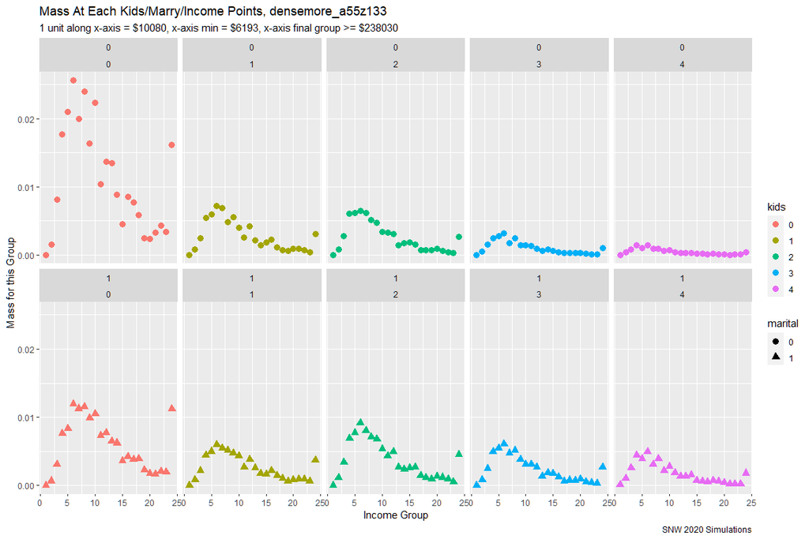

```r
# graph mean check amount by income, marital status and kids counts
lineplot_c <- df_alloc_i_long_covar_c %>%
  filter(rho_val == ar_rho[1]) %>% ungroup() %>%
  # filter(marital == 1) %>%
  mutate(ymin_group = as.numeric(ymin_group),
         kids = as.factor(kids),
         marital = as.factor(marital)) %>%
    ggplot(aes(x=ymin_group, y=mass ,
               colour=kids,
               shape=marital)) +
        facet_wrap( ~ marital + kids, ncol=5) +
        geom_point(size=3) +
        labs(title = paste0('Mass At Each Kids/Marry/Income Points, ',
                      st_file_type),
             subtitle = subtitle,
             x = 'Income Group',
             y = 'Mass for this Group',
             caption = 'SNW 2020 Simulations')
print(lineplot_c)
```

### Consumption Based Allocation Figure

Generate the needed dataframe, averaging over ages, averages by ymin, marital status, and kids count:

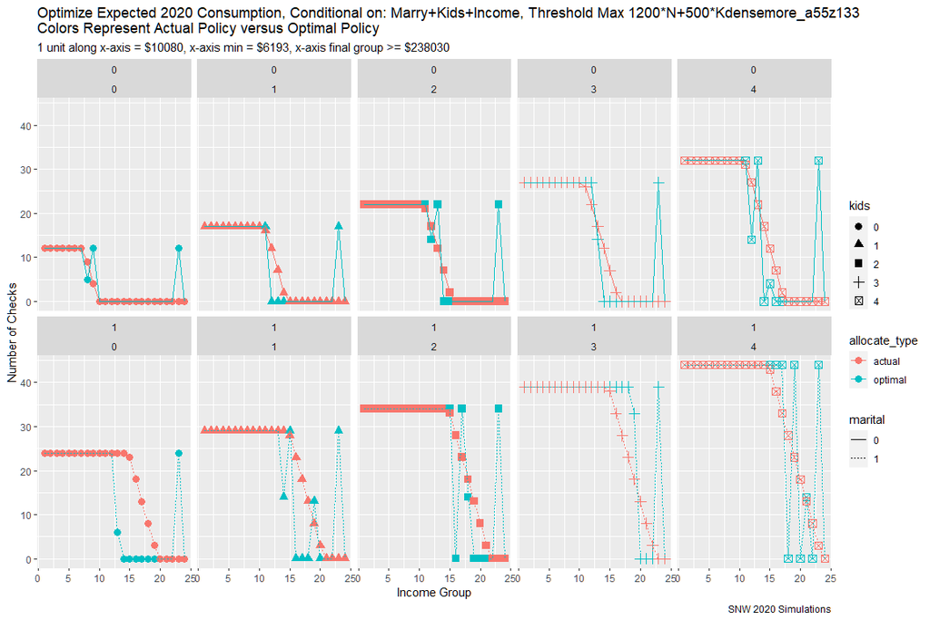

```r
# graph mean check amount by income, marital status and kids counts
lineplot_c <- df_alloc_i_long_covar_c %>%
  filter(rho_val == ar_rho[1]) %>% ungroup() %>%
  # filter(marital == 1) %>%
  mutate(ymin_group = as.numeric(ymin_group),
         kids = as.factor(kids),
         marital = as.factor(marital)) %>%
    ggplot(aes(x=ymin_group, y=checks,
               colour=allocate_type,
               shape=kids,
               linetype=marital)) +
        facet_wrap( ~ marital + kids, ncol=5) +
        geom_point(size=3) +
        geom_line() +
        labs(title = paste0('Optimize Expected 2020 Consumption, Conditional on: Marry+Kids+Income, Threshold Max 1200*N+500*K',
                      st_file_type, '\n', 'Colors Represent Actual Policy versus Optimal Policy'),
             subtitle = subtitle,
             x = 'Income Group',
             y = 'Number of Checks',
             caption = 'SNW 2020 Simulations')
print(lineplot_c)
```

### Lifetime Utility Allocation Figure

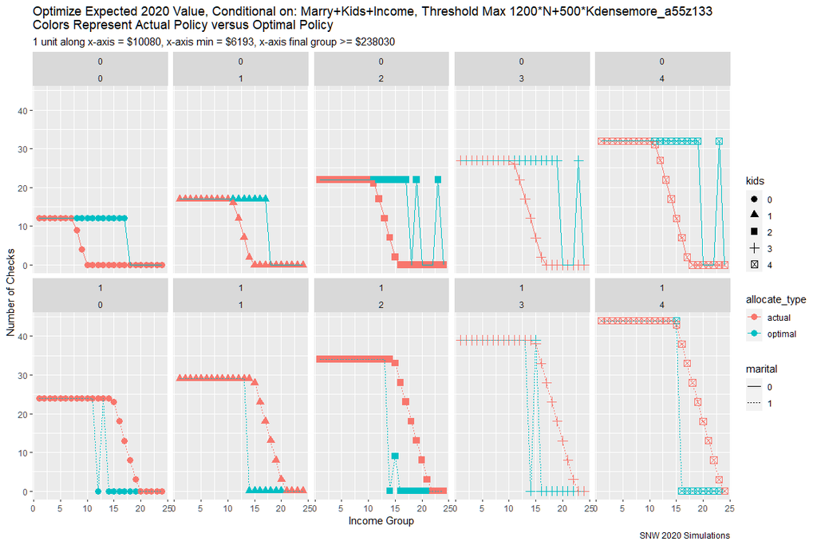

```r
# graph mean check amount by income, marital status and kids counts
lineplot_v <- df_alloc_i_long_covar_v %>%
  filter(rho_val == ar_rho[1]) %>% ungroup() %>%
  # filter(marital == 1) %>%
  mutate(ymin_group = as.numeric(ymin_group),
         kids = as.factor(kids),
         marital = as.factor(marital)) %>%
    ggplot(aes(x=ymin_group, y=checks,
               colour=allocate_type,
               shape=kids,
               linetype=marital)) +
        facet_wrap( ~ marital + kids, ncol=5) +
        geom_point(size=3) +
        geom_line() +
        labs(title =
               paste0('Optimize Expected 2020 Value, Conditional on: Marry+Kids+Income, Threshold Max 1200*N+500*K',
                      st_file_type, '\n', 'Colors Represent Actual Policy versus Optimal Policy'),
             subtitle = subtitle,
             x = 'Income Group',
             y = 'Number of Checks',
             caption = 'SNW 2020 Simulations')
print(lineplot_v)
```